# Home Credit Default Risk — Exploratory Data Analysis

IS 6812 Practice Project

Author

Ivania Zavidich-Fearnow

Published

September 20, 2026

This notebook executes the approved plan in `eda_plan.md` using only `application_train.csv`, `application_test.csv`, and the supplied column dictionary. All repairs are applied to derived DataFrames; the source CSVs are not modified. `TARGET = 1` denotes repayment difficulty and `TARGET = 0` denotes no repayment difficulty.

# 1 Business problem

Home Credit lends to applicants who often have little or no traditional credit history. As the business adapts its geographic footprint and considers expansion, it needs credit-risk decisions that remain reliable across different customer populations and market conditions. Borrower characteristics associated with repayment difficulty in one population may not perform the same way in another, and the cost of getting this wrong runs in two directions: approving higher-risk applicants raises delinquency and credit losses, while declining lower-risk applicants forgoes revenue and denies access to credit to people who would have repaid. The business need is to identify borrower characteristics that consistently indicate repayment difficulty — using variables that are available at application and straightforward to verify — and to express the result as a trade-off between the share of applicants approved and the observed rate of repayment difficulty. This dataset can identify candidate predictors; any cross-market use would require validation against current local data.

This notebook covers the exploratory stage: assessing data quality, screening candidate predictors, and checking whether the patterns hold across customer segments. Model fitting, threshold selection, and validation belong to the next stage.

TARGET = 1 denotes repayment difficulty and TARGET = 0 denotes no repayment difficulty. Scope is `application_train.csv` and `application_test.csv` only. Source CSVs are not modified; all repairs are applied to derived frames.

# 2 Questions

Eleven questions, in the order the plan established so that nothing depends on a result that comes later. Questions 1–6 are the standing data-integrity checks that open any EDA; questions 7–11 come from the business problem statement, the data map, and the feature report.

**Data integrity**

1. Is each in-scope table at the expected one-row-per-application grain, with a unique key and no duplicate rows? *(grain claim in the data map)*
2. What is the distribution of repayment difficulty in the training data, and what baseline does it imply? *(BPS: success is measured as an approval/difficulty trade-off, not accuracy)*
3. Are train and test consistent in columns, data types, and category levels? *(BPS: the recommendation must be deployable on the scoring population)*
4. Which values are impossible, undocumented sentinels, or implausible enough to distort later results? *(data map flagged the DAYS_EMPLOYED and CODE_GENDER contradictions)*
5. Were all proposed predictors known at the time of the application decision? *(BPS excludes anything not available at decision time)*
6. Is missingness a defect to repair, or a signal in its own right? *(BPS: variables must be readily available)*

**Analysis**

7. How much of the 122 columns is actually redundant? *(BPS promises a focused set of variables)*
8. Which individual applicant characteristics separate borrowers with repayment difficulty from those without, and is any one of them strong enough to stand alone? *(BPS: compare a transparent baseline with predictive alternatives)*
9. Do the money variables behave the way an underwriter would expect? *(feature report: affordability is a core underwriting family)*
10. Which predictors survive all three screens — predictive value, availability, and verifiability? *(BPS: a focused set of reliable, readily available, verifiable variables)*
11. Does the repayment-difficulty rate vary enough across major customer segments to threaten the stability the BPS promises? *(BPS: results must be checked for stability across major segments)*

Three questions this data cannot answer are recorded in the Limitations section: the revenue forgone on declined applicants, whether predictors transfer to another market, and whether any characteristic causes repayment difficulty.

# 3 Description of the data

**Grain and size.** One row is one current credit application — not one customer and not one originated loan. `application_train.csv` holds 307,511 rows and 122 columns; `application_test.csv` holds 48,744 rows and 121 columns. The only column difference is `TARGET`, which is absent from test by design.

**Key.** `SK_ID_CURR` is the primary key. It is non-null and unique in both files, and the two ID sets are disjoint, so no applicant appears in both. There is no person-level identifier, so repeat applicants cannot be detected or linked.

**Column groups.** The 122 columns fall into the following families:

| Group | Columns | Notes |
| --- | --- | --- |
| Identifier and target | 2 | `SK_ID_CURR`, `TARGET` |
| Loan contract | 4 | Contract type, credit, annuity, goods price |
| Demographics and household | 7 | Gender, age, family status, education, children, accompanying party |
| Income, employment, occupation | 5 | Income amount and type, employment duration, occupation, employer type |
| Assets and housing tenure | 4 | Car and realty ownership, car age, housing type |
| Building characteristics | 47 | Property measures in `_AVG` / `_MODE` / `_MEDI` variants |
| Contact flags | 6 | Phone, mobile, email availability |
| Document flags | 20 | `FLAG_DOCUMENT_2` through `FLAG_DOCUMENT_21` |
| Region and address consistency | 9 | Region rating, population, registration/work/live mismatches |
| External scores | 3 | `EXT_SOURCE_1/2/3` |
| Social circle | 4 | Observed and defaulted contacts at 30 and 60 days |
| Bureau enquiries | 6 | Credit bureau lookups over six time windows |
| Other relative-time fields | 3 | Registration, ID publish, last phone change |
| Application process timing | 2 | Weekday and hour the application was taken |

The building-characteristics family alone accounts for 47 of 122 columns — more than a third of the width of the table for a single construct measured three ways. That concentration is what motivates the redundancy question.

**Discrepancies between dictionary and data.** Five, from the data map and the checks in this notebook:

1. `DAYS_EMPLOYED` is documented as days *before* the application, but 55,374 training rows and 9,274 test rows hold the positive value 365243 — an undocumented sentinel of roughly 1,000 years.
2. `CODE_GENDER` contains the undocumented level `XNA` in 4 training rows. The dictionary gives no allowed category list.
3. `REGION_RATING_CLIENT_W_CITY` has a documented domain of 1, 2 or 3, but one test row holds −1.
4. The dictionary uses `SK_BUREAU_ID` where the supplementary CSVs use `SK_ID_BUREAU`, and lists `NFLAG_MICRO_CASH` for `previous_application`, a column absent from the file.
5. `sample_submission.csv` has no dictionary entry at all.

**Supplementary tables.** Not used at this stage, per the assignment scope. The data map records their coverage of training applicants for the modeling stage: `installments_payments` 94.84%, `previous_application` 94.65%, `POS_CASH_balance` 94.12%, `bureau` 85.69%, `bureau_balance` 29.99%, `credit_card_balance` 28.26%. The first three are the strongest candidates. For `bureau_balance` and `credit_card_balance`, which cover under 30% of applicants, an absent row cannot be read as good repayment behaviour.

```python
from pathlib import Path
import math
import warnings

import numpy as np
import pandas as pd
import matplotlib.pyplot as plt
import seaborn as sns
from scipy.stats import chi2_contingency
from sklearn.metrics import roc_auc_score
from sklearn.model_selection import train_test_split

warnings.filterwarnings("ignore")
pd.set_option("display.max_columns", 30)
pd.set_option("display.max_rows", 80)
pd.set_option("display.width", 160)
sns.set_theme(style="whitegrid", context="notebook")
RANDOM_STATE = 6812
MIN_GROUP = 1_000

def find_root(start=Path.cwd()):
    for candidate in [start, *start.parents]:
        if (candidate / "data" / "raw" / "application_train.csv").exists():
            return candidate
    raise FileNotFoundError("Run this notebook from within the Home-Credit-Project repository.")

ROOT = find_root()
RAW = ROOT / "data" / "raw"
train_raw = pd.read_csv(RAW / "application_train.csv", low_memory=False)
test_raw = pd.read_csv(RAW / "application_test.csv", low_memory=False)
dictionary = pd.read_csv(ROOT / "docs" / "HomeCredit_columns_description.csv", encoding="latin1")

def pct(x):
    return f"{x:.2%}"

def wilson(successes, n, z=1.96):
    if n == 0:
        return (np.nan, np.nan)
    p = successes / n
    den = 1 + z*z/n
    center = (p + z*z/(2*n)) / den
    half = z * math.sqrt((p*(1-p) + z*z/(4*n))/n) / den
    return center-half, center+half

print(f"Loaded train {train_raw.shape} and test {test_raw.shape} from {RAW.relative_to(ROOT)}.")
```

```
Loaded train (307511, 122) and test (48744, 121) from data/raw.
```

# 4 Data integrity

## 4.1 Q1. Is each in-scope table at the expected one-row-per-current-application grain, with a unique key and no duplicate rows?

```python
id_overlap = len(set(train_raw["SK_ID_CURR"]).intersection(test_raw["SK_ID_CURR"]))
integrity = []
for name, frame in [("application_train", train_raw), ("application_test", test_raw)]:
    duplicate_key_rows = int(frame["SK_ID_CURR"].duplicated(keep=False).sum())
    integrity.append({
        "table": name,
        "grain": "one current application row",
        "rows": len(frame),
        "columns": frame.shape[1],
        "null_keys": int(frame["SK_ID_CURR"].isna().sum()),
        "distinct_keys": int(frame["SK_ID_CURR"].nunique(dropna=True)),
        "duplicate_key_rows": duplicate_key_rows,
        "full_row_duplicates": int(frame.duplicated().sum()),
        "train_test_id_overlap": id_overlap,
    })
integrity_df = pd.DataFrame(integrity)
integrity_df
```

|  | table | grain | rows | columns | null_keys | distinct_keys | duplicate_key_rows | full_row_duplicates | train_test_id_overlap |
| --- | --- | --- | --- | --- | --- | --- | --- | --- | --- |
| 0 | application_train | one current application row | 307511 | 122 | 0 | 307511 | 0 | 0 | 0 |
| 1 | application_test | one current application row | 48744 | 121 | 0 | 48744 | 0 | 0 | 0 |

Each row here is a loan application, not a customer. The ID is unique per application and there is no person-level identifier, so if the same person applied more than once I have no way to link those rows — and no way to tell whether repeat applicants exist in this data at all. Every rate I report below is therefore a rate per application, and I should not describe any of them as customer default rates.

## 4.2 Q2. What is the distribution of repayment difficulty in the training data?

|  | TARGET | count | share |
| --- | --- | --- | --- |
| 0 | 0 | 282686 | 0.919271 |
| 1 | 1 | 24825 | 0.080729 |
| 2 | missing/invalid | 0 | 0.000000 |

```
Majority-class accuracy baseline: 91.93%
```

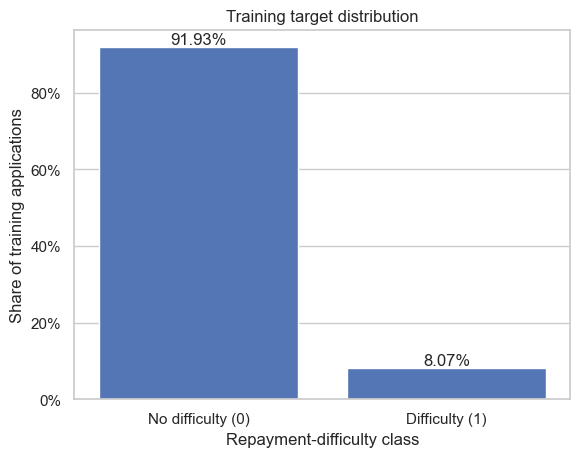

```python
valid_target = train_raw["TARGET"].isin([0, 1])
target_table = (
    train_raw.loc[valid_target, "TARGET"].value_counts(dropna=False).sort_index()
    .rename_axis("TARGET").reset_index(name="count")
)
target_table["share"] = target_table["count"] / len(train_raw)
invalid_count = int((~valid_target).sum())
target_table = pd.concat([
    target_table,
    pd.DataFrame([{"TARGET": "missing/invalid", "count": invalid_count, "share": invalid_count/len(train_raw)}])
], ignore_index=True)
majority_accuracy = train_raw["TARGET"].value_counts(normalize=True).max()
display(target_table)
print(f"Majority-class accuracy baseline: {majority_accuracy:.2%}")

plot_target = target_table[target_table["TARGET"].isin([0, 1])].copy()
plot_target["label"] = plot_target["TARGET"].map({0: "No difficulty (0)", 1: "Difficulty (1)"})
ax = sns.barplot(data=plot_target, x="label", y="share", color="#4472C4")
ax.set(title="Training target distribution", xlabel="Repayment-difficulty class", ylabel="Share of training applications")
ax.yaxis.set_major_formatter(plt.FuncFormatter(lambda y, _: f"{y:.0%}"))
for patch, share in zip(ax.patches, plot_target["share"]):
    ax.text(patch.get_x()+patch.get_width()/2, patch.get_height(), f"{share:.2%}", ha="center", va="bottom")
plt.show()
```

Only 8.07% of applicants had payment trouble. That means a model that approved everyone would be 91.93% accurate and would still approve every borrower who defaults. Accuracy is the wrong way to judge this problem. That is why my business problem statement measures success as a trade-off between how many people we approve and how many of them run into trouble.

## 4.3 Q3. Are train and test consistent in columns, data types, and categorical levels?

```python
train_only = sorted(set(train_raw.columns) - set(test_raw.columns))
test_only = sorted(set(test_raw.columns) - set(train_raw.columns))
schema_diff = pd.DataFrame({
    "comparison": ["train-only columns", "test-only columns"],
    "columns": [", ".join(train_only) or "None", ", ".join(test_only) or "None"],
    "status": ["Expected" if train_only == ["TARGET"] else "Review", "Expected" if not test_only else "Review"],
})

common_cols = sorted(set(train_raw.columns).intersection(test_raw.columns))
dtype_mismatch = pd.DataFrame([
    {"field": c, "train_dtype": str(train_raw[c].dtype), "test_dtype": str(test_raw[c].dtype)}
    for c in common_cols if train_raw[c].dtype != test_raw[c].dtype
])

level_rows = []
cat_cols = [c for c in common_cols if train_raw[c].dtype == "object" or test_raw[c].dtype == "object"]
for c in cat_cols:
    tr = train_raw[c].fillna("<MISSING>").astype(str)
    te = test_raw[c].fillna("<MISSING>").astype(str)
    for level in sorted(set(tr.unique()) - set(te.unique())):
        n = int((tr == level).sum())
        level_rows.append({"field": c, "level": level, "split": "train only", "count": n, "share": n/len(tr)})
    for level in sorted(set(te.unique()) - set(tr.unique())):
        n = int((te == level).sum())
        level_rows.append({"field": c, "level": level, "split": "test only", "count": n, "share": n/len(te)})
level_mismatch = pd.DataFrame(level_rows).sort_values(["field", "split", "count"], ascending=[True, True, False])

constant_rows = []
for c in common_cols:
    for split, frame in [("train", train_raw), ("test", test_raw)]:
        if frame[c].nunique(dropna=False) <= 1:
            constant_rows.append({"field": c, "split": split, "unique_including_missing": frame[c].nunique(dropna=False)})
constant_columns = pd.DataFrame(constant_rows)

display(schema_diff)
display(dtype_mismatch if not dtype_mismatch.empty else pd.DataFrame({"result": ["No dtype mismatches"]}))
display(level_mismatch if not level_mismatch.empty else pd.DataFrame({"result": ["No categorical level mismatches"]}))
display(constant_columns if not constant_columns.empty else pd.DataFrame({"result": ["No entirely missing or constant common columns"]}))
```

|  | comparison | columns | status |
| --- | --- | --- | --- |
| 0 | train-only columns | TARGET | Expected |
| 1 | test-only columns | None | Expected |

|  | result |
| --- | --- |
| 0 | No dtype mismatches |

|  | field | level | split | count | share |
| --- | --- | --- | --- | --- | --- |
| 0 | CODE_GENDER | XNA | train only | 4 | 0.000013 |
| 1 | NAME_FAMILY_STATUS | Unknown | train only | 2 | 0.000007 |
| 2 | NAME_INCOME_TYPE | Maternity leave | train only | 5 | 0.000016 |

|  | field | split | unique_including_missing |
| --- | --- | --- | --- |
| 0 | FLAG_DOCUMENT_10 | test | 1 |
| 1 | FLAG_DOCUMENT_12 | test | 1 |
| 2 | FLAG_DOCUMENT_13 | test | 1 |
| 3 | FLAG_DOCUMENT_14 | test | 1 |
| 4 | FLAG_DOCUMENT_15 | test | 1 |
| 5 | FLAG_DOCUMENT_16 | test | 1 |
| 6 | FLAG_DOCUMENT_17 | test | 1 |
| 7 | FLAG_DOCUMENT_19 | test | 1 |
| 8 | FLAG_DOCUMENT_2 | test | 1 |
| 9 | FLAG_DOCUMENT_20 | test | 1 |
| 10 | FLAG_DOCUMENT_21 | test | 1 |

The two files line up well. The only column missing from test is TARGET, which is expected.

Three categories appear in training and never in test: XNA gender, Unknown family status, and Maternity leave. These do not break scoring. An encoder fitted on training data simply produces a column that is always zero at predict time. The risk runs the other way — a category present in test but absent from training is what an encoder cannot represent — and I found no test-only categories.

The more consequential finding is that eleven of the FLAG_DOCUMENT columns hold the same value for every test applicant. They cannot separate anyone in the population I actually have to score, however they behave in training.

## 4.4 Q4. Which values are impossible, undocumented sentinels, or implausible enough to distort later results?

```python
income_plot_cap = train_raw["AMT_INCOME_TOTAL"].quantile(0.999)
social_cols = [c for c in train_raw.columns if (c.startswith("OBS_") or c.startswith("DEF_")) and c.endswith("CNT_SOCIAL_CIRCLE")]

anomaly_register = pd.DataFrame([
    {
        "column": "DAYS_EMPLOYED", "rule": "relative application days must not be +365243",
        "offending_value_or_range": "365243", "train_count": int((train_raw.DAYS_EMPLOYED == 365243).sum()),
        "train_share": (train_raw.DAYS_EMPLOYED == 365243).mean(), "test_count": int((test_raw.DAYS_EMPLOYED == 365243).sum()),
        "test_share": (test_raw.DAYS_EMPLOYED == 365243).mean(), "classification": "undocumented sentinel",
        "treatment": "set NaN; add FLAG_NOT_EMPLOYED; retain rows",
    },
    {
        "column": "CODE_GENDER", "rule": "undocumented XNA level", "offending_value_or_range": "XNA",
        "train_count": int((train_raw.CODE_GENDER == "XNA").sum()), "train_share": (train_raw.CODE_GENDER == "XNA").mean(),
        "test_count": int((test_raw.CODE_GENDER == "XNA").sum()), "test_share": (test_raw.CODE_GENDER == "XNA").mean(),
        "classification": "undocumented category", "treatment": "drop train rows; never drop test rows",
    },
    {
        "column": "REGION_RATING_CLIENT_W_CITY", "rule": "dictionary domain is 1, 2, or 3", "offending_value_or_range": "-1",
        "train_count": int((train_raw.REGION_RATING_CLIENT_W_CITY == -1).sum()), "train_share": (train_raw.REGION_RATING_CLIENT_W_CITY == -1).mean(),
        "test_count": int((test_raw.REGION_RATING_CLIENT_W_CITY == -1).sum()), "test_share": (test_raw.REGION_RATING_CLIENT_W_CITY == -1).mean(),
        "classification": "impossible by dictionary", "treatment": "replace test value with training mode",
    },
    {
        "column": "AMT_INCOME_TOTAL", "rule": "inspect extreme relative to training 99.9th percentile",
        "offending_value_or_range": f"max={train_raw.AMT_INCOME_TOTAL.max():,.0f}; p99.9={income_plot_cap:,.0f}",
        "train_count": int((train_raw.AMT_INCOME_TOTAL > income_plot_cap).sum()), "train_share": (train_raw.AMT_INCOME_TOTAL > income_plot_cap).mean(),
        "test_count": int((test_raw.AMT_INCOME_TOTAL > income_plot_cap).sum()), "test_share": (test_raw.AMT_INCOME_TOTAL > income_plot_cap).mean(),
        "classification": "extreme; validity unresolved", "treatment": "retain raw; cap plots only at training p99.9",
    },
    {
        "column": "OBS_*/DEF_*_CNT_SOCIAL_CIRCLE", "rule": "inspect unusually large social-circle counts",
        "offending_value_or_range": f"train max={train_raw[social_cols].max().max():.0f}; test max={test_raw[social_cols].max().max():.0f}",
        "train_count": int((train_raw[social_cols] > 100).any(axis=1).sum()), "train_share": (train_raw[social_cols] > 100).any(axis=1).mean(),
        "test_count": int((test_raw[social_cols] > 100).any(axis=1).sum()), "test_share": (test_raw[social_cols] > 100).any(axis=1).mean(),
        "classification": "implausible/suspect", "treatment": "retain; flag; exclude from headline claims",
    },
])
display(anomaly_register)

train = train_raw.copy()
test = test_raw.copy()
train["FLAG_NOT_EMPLOYED"] = (train["DAYS_EMPLOYED"] == 365243).astype("int8")
test["FLAG_NOT_EMPLOYED"] = (test["DAYS_EMPLOYED"] == 365243).astype("int8")
train.loc[train["DAYS_EMPLOYED"] == 365243, "DAYS_EMPLOYED"] = np.nan
test.loc[test["DAYS_EMPLOYED"] == 365243, "DAYS_EMPLOYED"] = np.nan
train_before_xna = len(train)
train = train.loc[train["CODE_GENDER"] != "XNA"].copy()
city_mode = train["REGION_RATING_CLIENT_W_CITY"].mode().iat[0]
test.loc[test["REGION_RATING_CLIENT_W_CITY"] == -1, "REGION_RATING_CLIENT_W_CITY"] = city_mode
transformation_log = pd.DataFrame([
    {"operation": "remove train CODE_GENDER=XNA", "before_rows": train_before_xna, "after_rows": len(train), "rows_changed": train_before_xna-len(train)},
    {"operation": "repair test REGION_RATING_CLIENT_W_CITY=-1", "before_rows": len(test_raw), "after_rows": len(test), "rows_changed": int((test_raw.REGION_RATING_CLIENT_W_CITY == -1).sum())},
    {"operation": "recode DAYS_EMPLOYED sentinel in derived frames", "before_rows": len(train_raw)+len(test_raw), "after_rows": len(train)+len(test), "rows_changed": int((train_raw.DAYS_EMPLOYED == 365243).sum() + (test_raw.DAYS_EMPLOYED == 365243).sum())},
])
display(transformation_log)
```

|  | column | rule | offending_value_or_range | train_count | train_share | test_count | test_share | classification | treatment |
| --- | --- | --- | --- | --- | --- | --- | --- | --- | --- |
| 0 | DAYS_EMPLOYED | relative application days must not be +365243 | 365243 | 55374 | 0.180072 | 9274 | 0.190259 | undocumented sentinel | set NaN; add FLAG_NOT_EMPLOYED; retain rows |
| 1 | CODE_GENDER | undocumented XNA level | XNA | 4 | 0.000013 | 0 | 0.000000 | undocumented category | drop train rows; never drop test rows |
| 2 | REGION_RATING_CLIENT_W_CITY | dictionary domain is 1, 2, or 3 | -1 | 0 | 0.000000 | 1 | 0.000021 | impossible by dictionary | replace test value with training mode |
| 3 | AMT_INCOME_TOTAL | inspect extreme relative to training 99.9th pe... | max=117,000,000; p99.9=900,000 | 278 | 0.000904 | 42 | 0.000862 | extreme; validity unresolved | retain raw; cap plots only at training p99.9 |
| 4 | OBS_*/DEF_*_CNT_SOCIAL_CIRCLE | inspect unusually large social-circle counts | train max=348; test max=354 | 1 | 0.000003 | 3 | 0.000062 | implausible/suspect | retain; flag; exclude from headline claims |

|  | operation | before_rows | after_rows | rows_changed |
| --- | --- | --- | --- | --- |
| 0 | remove train CODE_GENDER=XNA | 307511 | 307507 | 4 |
| 1 | repair test REGION_RATING_CLIENT_W_CITY=-1 | 48744 | 48744 | 1 |
| 2 | recode DAYS_EMPLOYED sentinel in derived frames | 356255 | 356251 | 64648 |

My biggest data problem is DAYS_EMPLOYED. In 55,374 rows, about 18% of the data, it equals 365243, which is roughly 1,000 years. That is not a real measurement, it is a sentinel value.

Checking who carries it: 55,352 of those rows are pensioners and 22 are unemployed. So it marks pensioners far more than it marks absence of employment in general. I replaced the value with a missing value and added a flag column, but the flag should be read as a pensioner marker rather than a general “not employed” indicator, and the dictionary does not document what the code actually means.

I did not delete these rows. They are 18% of my data and they behave differently from everyone else, so dropping them would change the population I am studying. I did remove the 4 rows with an XNA gender, since 4 out of 307,511 cannot affect anything. But I repaired the one test row with an impossible region rating instead of deleting it, because every test applicant has to get a prediction.

## 4.5 Q5. Were all proposed predictors known at the current application decision time?

```python
timing_inventory = pd.DataFrame([
    {"field_or_family": "TARGET", "timing_class": "outcome", "evidence": "dictionary: target variable", "leakage_risk": "certain", "decision": "exclude"},
    {"field_or_family": "SK_ID_CURR", "timing_class": "identifier", "evidence": "application-table key", "leakage_risk": "identifier memorization", "decision": "exclude"},
    {"field_or_family": "DAYS_BIRTH / DAYS_EMPLOYED / DAYS_REGISTRATION / DAYS_ID_PUBLISH / DAYS_LAST_PHONE_CHANGE", "timing_class": "pre-application history", "evidence": "dictionary defines days relative to application; post-S4 values are non-positive", "leakage_risk": "low after sentinel repair", "decision": "keep"},
    {"field_or_family": "AMT_REQ_CREDIT_BUREAU_*", "timing_class": "pre-application history", "evidence": "dictionary describes bureau enquiries before application", "leakage_risk": "low", "decision": "keep"},
    {"field_or_family": "EXT_SOURCE_1 / EXT_SOURCE_2 / EXT_SOURCE_3", "timing_class": "timing/provenance unclear", "evidence": "dictionary says normalized external score but gives no provider timestamp or construction", "leakage_risk": "review", "decision": "review"},
    {"field_or_family": "application attributes, amounts, ownership, contact, region, document and housing fields", "timing_class": "application-time input", "evidence": "application table and dictionary descriptions", "leakage_risk": "low; provenance not independently timestamped", "decision": "keep/review for governance"},
    {"field_or_family": "FLAG_NOT_EMPLOYED", "timing_class": "derived application-time indicator", "evidence": "derived from DAYS_EMPLOYED sentinel", "leakage_risk": "low after documented derivation", "decision": "keep"},
])

days_cols = [c for c in train.columns if c.startswith("DAYS_")]
days_sign_check = pd.DataFrame({
    "field": days_cols,
    "positive_after_treatment": [int((train[c] > 0).sum()) for c in days_cols],
    "zero_count": [int((train[c] == 0).sum()) for c in days_cols],
    "minimum": [train[c].min() for c in days_cols],
    "maximum": [train[c].max() for c in days_cols],
})
display(timing_inventory)
display(days_sign_check)
```

|  | field_or_family | timing_class | evidence | leakage_risk | decision |
| --- | --- | --- | --- | --- | --- |
| 0 | TARGET | outcome | dictionary: target variable | certain | exclude |
| 1 | SK_ID_CURR | identifier | application-table key | identifier memorization | exclude |
| 2 | DAYS_BIRTH / DAYS_EMPLOYED / DAYS_REGISTRATION... | pre-application history | dictionary defines days relative to applicatio... | low after sentinel repair | keep |
| 3 | AMT_REQ_CREDIT_BUREAU_* | pre-application history | dictionary describes bureau enquiries before a... | low | keep |
| 4 | EXT_SOURCE_1 / EXT_SOURCE_2 / EXT_SOURCE_3 | timing/provenance unclear | dictionary says normalized external score but ... | review | review |
| 5 | application attributes, amounts, ownership, co... | application-time input | application table and dictionary descriptions | low; provenance not independently timestamped | keep/review for governance |
| 6 | FLAG_NOT_EMPLOYED | derived application-time indicator | derived from DAYS_EMPLOYED sentinel | low after documented derivation | keep |

|  | field | positive_after_treatment | zero_count | minimum | maximum |
| --- | --- | --- | --- | --- | --- |
| 0 | DAYS_BIRTH | 0 | 0 | -25229.0 | -7489.0 |
| 1 | DAYS_EMPLOYED | 0 | 2 | -17912.0 | 0.0 |
| 2 | DAYS_REGISTRATION | 0 | 80 | -24672.0 | 0.0 |
| 3 | DAYS_ID_PUBLISH | 0 | 16 | -7197.0 | 0.0 |
| 4 | DAYS_LAST_PHONE_CHANGE | 0 | 37672 | -4292.0 | 0.0 |

After fixing DAYS_EMPLOYED, every date column is negative, which matches the dictionary. Negative means the event happened before the application, so nothing in this table describes what happened after the loan was approved. The exception is the three EXT_SOURCE columns. The dictionary only says they are normalized scores from an outside source. I do not know who built them, what goes into them, or when they were measured, so I cannot confirm they were known at application time.

## 4.6 Q6. Is missingness a defect to repair, or a signal in itself?

|  | field | train_missing_n | train_missing_share | test_missing_n | test_missing_share | test_minus_train_pp |
| --- | --- | --- | --- | --- | --- | --- |
| 0 | COMMONAREA_MODE | 214862 | 0.698722 | 33495 | 0.687161 | -1.156081 |
| 1 | COMMONAREA_AVG | 214862 | 0.698722 | 33495 | 0.687161 | -1.156081 |
| 2 | COMMONAREA_MEDI | 214862 | 0.698722 | 33495 | 0.687161 | -1.156081 |
| 3 | NONLIVINGAPARTMENTS_MEDI | 213512 | 0.694332 | 33347 | 0.684125 | -1.020694 |
| 4 | NONLIVINGAPARTMENTS_MODE | 213512 | 0.694332 | 33347 | 0.684125 | -1.020694 |
| 5 | NONLIVINGAPARTMENTS_AVG | 213512 | 0.694332 | 33347 | 0.684125 | -1.020694 |
| 6 | FONDKAPREMONT_MODE | 210293 | 0.683864 | 32797 | 0.672842 | -1.102232 |
| 7 | LIVINGAPARTMENTS_MEDI | 210197 | 0.683552 | 32780 | 0.672493 | -1.105889 |
| 8 | LIVINGAPARTMENTS_AVG | 210197 | 0.683552 | 32780 | 0.672493 | -1.105889 |
| 9 | LIVINGAPARTMENTS_MODE | 210197 | 0.683552 | 32780 | 0.672493 | -1.105889 |
| 10 | FLOORSMIN_MEDI | 208640 | 0.678489 | 32466 | 0.666051 | -1.243741 |
| 11 | FLOORSMIN_AVG | 208640 | 0.678489 | 32466 | 0.666051 | -1.243741 |
| 12 | FLOORSMIN_MODE | 208640 | 0.678489 | 32466 | 0.666051 | -1.243741 |
| 13 | YEARS_BUILD_AVG | 204486 | 0.664980 | 31818 | 0.652757 | -1.222272 |
| 14 | YEARS_BUILD_MODE | 204486 | 0.664980 | 31818 | 0.652757 | -1.222272 |
| 15 | YEARS_BUILD_MEDI | 204486 | 0.664980 | 31818 | 0.652757 | -1.222272 |
| 16 | OWN_CAR_AGE | 202927 | 0.659910 | 32312 | 0.662892 | 0.298166 |
| 17 | LANDAREA_AVG | 182588 | 0.593769 | 28254 | 0.579641 | -1.412803 |
| 18 | LANDAREA_MODE | 182588 | 0.593769 | 28254 | 0.579641 | -1.412803 |
| 19 | LANDAREA_MEDI | 182588 | 0.593769 | 28254 | 0.579641 | -1.412803 |

|  | field | missing_n | present_n | missing_target_rate | present_target_rate | absolute_difference | relative_lift | difference_ci_low | difference_ci_high | recommendation | minimum_group_n |
| --- | --- | --- | --- | --- | --- | --- | --- | --- | --- | --- | --- |
| 0 | HOUSETYPE_MODE | 154296 | 153211 | 0.091512 | 0.069871 | 0.021641 | 1.309735 | 0.019718 | 0.023565 | impute plus indicator | 153211 |
| 1 | LIVINGAREA_AVG | 154349 | 153158 | 0.091423 | 0.069954 | 0.021469 | 1.306899 | 0.019545 | 0.023392 | impute plus indicator | 153158 |
| 2 | LIVINGAREA_MODE | 154349 | 153158 | 0.091423 | 0.069954 | 0.021469 | 1.306899 | 0.019545 | 0.023392 | impute plus indicator | 153158 |
| 3 | LIVINGAREA_MEDI | 154349 | 153158 | 0.091423 | 0.069954 | 0.021469 | 1.306899 | 0.019545 | 0.023392 | impute plus indicator | 153158 |
| 4 | FLOORSMAX_AVG | 153019 | 154488 | 0.091910 | 0.069656 | 0.022254 | 1.319489 | 0.020329 | 0.024180 | impute plus indicator | 153019 |
| 5 | FLOORSMAX_MODE | 153019 | 154488 | 0.091910 | 0.069656 | 0.022254 | 1.319489 | 0.020329 | 0.024180 | impute plus indicator | 153019 |
| 6 | FLOORSMAX_MEDI | 153019 | 154488 | 0.091910 | 0.069656 | 0.022254 | 1.319489 | 0.020329 | 0.024180 | impute plus indicator | 153019 |
| 7 | ENTRANCES_AVG | 154827 | 152680 | 0.091786 | 0.069518 | 0.022268 | 1.320325 | 0.020346 | 0.024191 | impute plus indicator | 152680 |
| 8 | ENTRANCES_MODE | 154827 | 152680 | 0.091786 | 0.069518 | 0.022268 | 1.320325 | 0.020346 | 0.024191 | impute plus indicator | 152680 |
| 9 | ENTRANCES_MEDI | 154827 | 152680 | 0.091786 | 0.069518 | 0.022268 | 1.320325 | 0.020346 | 0.024191 | impute plus indicator | 152680 |
| 10 | APARTMENTS_AVG | 156060 | 151447 | 0.091535 | 0.069595 | 0.021940 | 1.315251 | 0.020019 | 0.023861 | impute plus indicator | 151447 |
| 11 | APARTMENTS_MODE | 156060 | 151447 | 0.091535 | 0.069595 | 0.021940 | 1.315251 | 0.020019 | 0.023861 | impute plus indicator | 151447 |
| 12 | APARTMENTS_MEDI | 156060 | 151447 | 0.091535 | 0.069595 | 0.021940 | 1.315251 | 0.020019 | 0.023861 | impute plus indicator | 151447 |
| 13 | WALLSMATERIAL_MODE | 156340 | 151167 | 0.091282 | 0.069817 | 0.021465 | 1.307447 | 0.019544 | 0.023386 | impute plus indicator | 151167 |
| 14 | YEARS_BEGINEXPLUATATION_AVG | 150006 | 157501 | 0.092050 | 0.069949 | 0.022101 | 1.315958 | 0.020170 | 0.024031 | impute plus indicator | 150006 |
| 15 | YEARS_BEGINEXPLUATATION_MODE | 150006 | 157501 | 0.092050 | 0.069949 | 0.022101 | 1.315958 | 0.020170 | 0.024031 | impute plus indicator | 150006 |
| 16 | YEARS_BEGINEXPLUATATION_MEDI | 150006 | 157501 | 0.092050 | 0.069949 | 0.022101 | 1.315958 | 0.020170 | 0.024031 | impute plus indicator | 150006 |
| 17 | TOTALAREA_MODE | 148430 | 159077 | 0.092340 | 0.069897 | 0.022443 | 1.321085 | 0.020509 | 0.024377 | impute plus indicator | 148430 |
| 18 | EMERGENCYSTATE_MODE | 145754 | 161753 | 0.092608 | 0.070027 | 0.022582 | 1.322472 | 0.020642 | 0.024521 | impute plus indicator | 145754 |
| 19 | ELEVATORS_AVG | 163890 | 143617 | 0.091006 | 0.069003 | 0.022003 | 1.318873 | 0.020091 | 0.023916 | impute plus indicator | 143617 |

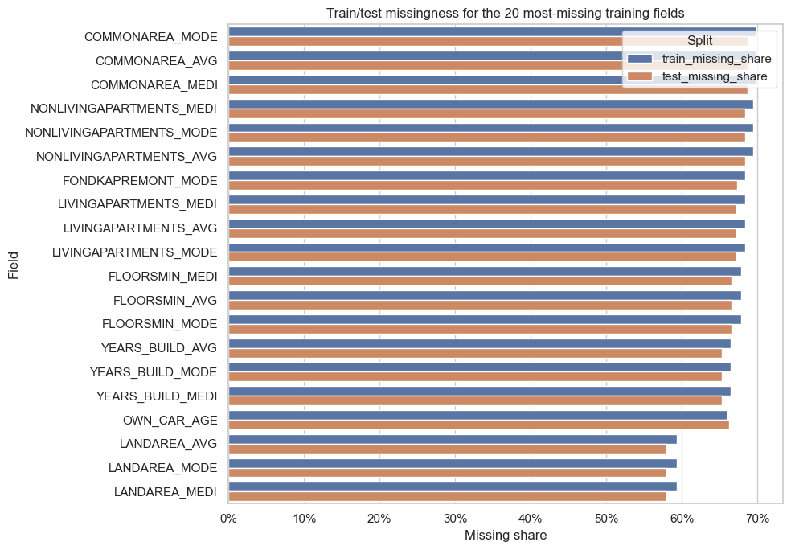

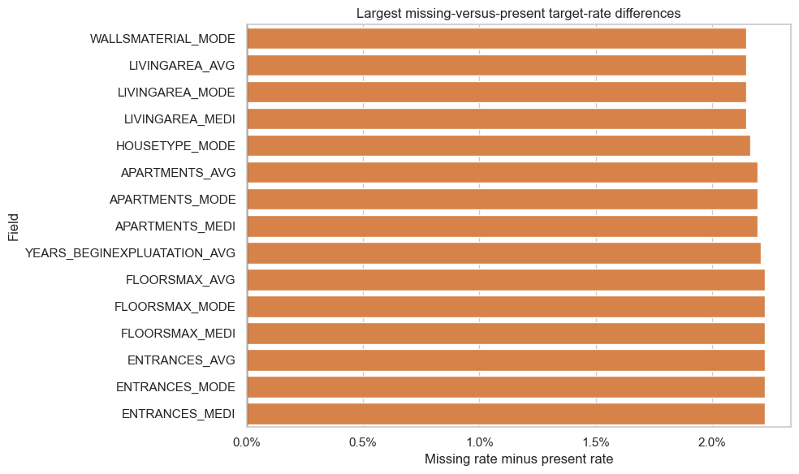

```python
candidate_cols = [c for c in test.columns if c != "SK_ID_CURR"]
missing_rows = []
association_rows = []
for c in candidate_cols:
    tr_miss = train[c].isna()
    te_miss = test[c].isna()
    tr_share, te_share = tr_miss.mean(), te_miss.mean()
    missing_rows.append({
        "field": c, "train_missing_n": int(tr_miss.sum()), "train_missing_share": tr_share,
        "test_missing_n": int(te_miss.sum()), "test_missing_share": te_share,
        "test_minus_train_pp": 100*(te_share-tr_share),
    })
    n_miss, n_present = int(tr_miss.sum()), int((~tr_miss).sum())
    if n_miss and n_present:
        y_miss = train.loc[tr_miss, "TARGET"]
        y_present = train.loc[~tr_miss, "TARGET"]
        r_miss, r_present = y_miss.mean(), y_present.mean()
        se = math.sqrt(r_miss*(1-r_miss)/n_miss + r_present*(1-r_present)/n_present)
        diff = r_miss-r_present
        if min(n_miss, n_present) < MIN_GROUP:
            recommendation = "exclude/review (tiny group)"
        elif tr_share > .60:
            recommendation = "exclude/review"
        elif abs(diff) >= .005:
            recommendation = "impute plus indicator"
        elif tr_share > 0:
            recommendation = "impute"
        else:
            recommendation = "retain as value"
        association_rows.append({
            "field": c, "missing_n": n_miss, "present_n": n_present,
            "missing_target_rate": r_miss, "present_target_rate": r_present,
            "absolute_difference": diff, "relative_lift": r_miss/r_present if r_present else np.nan,
            "difference_ci_low": diff-1.96*se, "difference_ci_high": diff+1.96*se,
            "recommendation": recommendation,
        })

missingness = pd.DataFrame(missing_rows).sort_values("train_missing_share", ascending=False).reset_index(drop=True)
missing_association = pd.DataFrame(association_rows)
missing_association["minimum_group_n"] = missing_association[["missing_n", "present_n"]].min(axis=1)
missing_association = missing_association.sort_values(
    ["minimum_group_n", "absolute_difference"],
    key=lambda s: s.abs() if s.name == "absolute_difference" else s,
    ascending=[False, False],
).reset_index(drop=True)
display(missingness.head(20))
display(missing_association.head(20))

plot_miss = missingness.head(20).melt(
    id_vars="field", value_vars=["train_missing_share", "test_missing_share"],
    var_name="split", value_name="missing_share"
)
plt.figure(figsize=(10, 7))
ax = sns.barplot(data=plot_miss, y="field", x="missing_share", hue="split")
ax.set(title="Train/test missingness for the 20 most-missing training fields", xlabel="Missing share", ylabel="Field")
ax.xaxis.set_major_formatter(plt.FuncFormatter(lambda x, _: f"{x:.0%}"))
plt.legend(title="Split")
plt.tight_layout()
plt.show()

plot_assoc = missing_association.head(15).sort_values("absolute_difference")
plt.figure(figsize=(10, 6))
ax = sns.barplot(data=plot_assoc, y="field", x="absolute_difference", color="#ED7D31")
ax.axvline(0, color="black", linewidth=1)
ax.set(title="Largest missing-versus-present target-rate differences", xlabel="Missing rate minus present rate", ylabel="Field")
ax.xaxis.set_major_formatter(plt.FuncFormatter(lambda x, _: f"{x:.1%}"))
plt.tight_layout()
plt.show()
```

Missing values here are not random. Applicants missing HOUSETYPE_MODE default at 9.15%, while applicants who have it default at 6.99%. The fact that a value is missing tells me something on its own.

The building columns are missing in overlapping blocks rather than identically. Across the 47 building-related fields there are 19 distinct missingness patterns, so this is not one shared cause but a property data source with uneven coverage. If I filled these in with an average I would erase whatever signal the absence carries, so I would add a flag marking the value as missing instead.

# 5 Q7. How much of the 122 columns is actually redundant?

|  | metric | count |
| --- | --- | --- |
| 0 | candidate columns before grouping | 121 |
| 1 | constant columns | 0 |
| 2 | exact duplicate groups | 0 |
| 3 | numeric \|Spearman rho\| >= 0.90 pairs | 71 |
| 4 | numeric redundancy groups | 15 |
| 5 | usable groups after constants and numeric grou... | 85 |

|  | group | members | member_count | proposed_representative | representative_coverage |
| --- | --- | --- | --- | --- | --- |
| 0 | 1 | APARTMENTS_AVG, APARTMENTS_MEDI, APARTMENTS_MO... | 10 | TOTALAREA_MODE | 0.517312 |
| 1 | 2 | YEARS_BEGINEXPLUATATION_AVG, YEARS_BEGINEXPLUA... | 6 | YEARS_BEGINEXPLUATATION_AVG | 0.512187 |
| 2 | 3 | BASEMENTAREA_AVG, BASEMENTAREA_MEDI, BASEMENTA... | 3 | BASEMENTAREA_AVG | 0.414836 |
| 3 | 4 | COMMONAREA_AVG, COMMONAREA_MEDI, COMMONAREA_MODE | 3 | COMMONAREA_AVG | 0.301278 |
| 4 | 5 | ELEVATORS_AVG, ELEVATORS_MEDI, ELEVATORS_MODE | 3 | ELEVATORS_AVG | 0.467037 |
| 5 | 6 | ENTRANCES_AVG, ENTRANCES_MEDI, ENTRANCES_MODE | 3 | ENTRANCES_AVG | 0.496509 |
| 6 | 7 | FLOORSMAX_AVG, FLOORSMAX_MEDI, FLOORSMAX_MODE | 3 | FLOORSMAX_AVG | 0.502389 |
| 7 | 8 | FLOORSMIN_AVG, FLOORSMIN_MEDI, FLOORSMIN_MODE | 3 | FLOORSMIN_AVG | 0.321511 |
| 8 | 9 | LANDAREA_AVG, LANDAREA_MEDI, LANDAREA_MODE | 3 | LANDAREA_AVG | 0.406231 |
| 9 | 10 | NONLIVINGAPARTMENTS_AVG, NONLIVINGAPARTMENTS_M... | 3 | NONLIVINGAPARTMENTS_AVG | 0.305668 |
| 10 | 11 | NONLIVINGAREA_AVG, NONLIVINGAREA_MEDI, NONLIVI... | 3 | NONLIVINGAREA_AVG | 0.448208 |
| 11 | 12 | AMT_CREDIT, AMT_GOODS_PRICE | 2 | AMT_CREDIT | 1.000000 |
| 12 | 13 | FLAG_EMP_PHONE, FLAG_NOT_EMPLOYED | 2 | FLAG_EMP_PHONE | 1.000000 |
| 13 | 14 | OBS_30_CNT_SOCIAL_CIRCLE, OBS_60_CNT_SOCIAL_CI... | 2 | OBS_30_CNT_SOCIAL_CIRCLE | 0.996680 |
| 14 | 15 | REGION_RATING_CLIENT, REGION_RATING_CLIENT_W_CITY | 2 | REGION_RATING_CLIENT | 1.000000 |

|  | field_1 | field_2 | cramers_v |
| --- | --- | --- | --- |
| 119 | WALLSMATERIAL_MODE | EMERGENCYSTATE_MODE | 0.689064 |
| 118 | HOUSETYPE_MODE | EMERGENCYSTATE_MODE | 0.669268 |
| 117 | HOUSETYPE_MODE | WALLSMATERIAL_MODE | 0.559750 |
| 22 | CODE_GENDER | OCCUPATION_TYPE | 0.507719 |
| 116 | FONDKAPREMONT_MODE | EMERGENCYSTATE_MODE | 0.461358 |
| 70 | NAME_INCOME_TYPE | ORGANIZATION_TYPE | 0.422383 |
| 114 | FONDKAPREMONT_MODE | HOUSETYPE_MODE | 0.395580 |
| 115 | FONDKAPREMONT_MODE | WALLSMATERIAL_MODE | 0.350262 |
| 15 | CODE_GENDER | FLAG_OWN_CAR | 0.345844 |
| 24 | CODE_GENDER | ORGANIZATION_TYPE | 0.337176 |
| 100 | OCCUPATION_TYPE | ORGANIZATION_TYPE | 0.323272 |
| 68 | NAME_INCOME_TYPE | OCCUPATION_TYPE | 0.289244 |

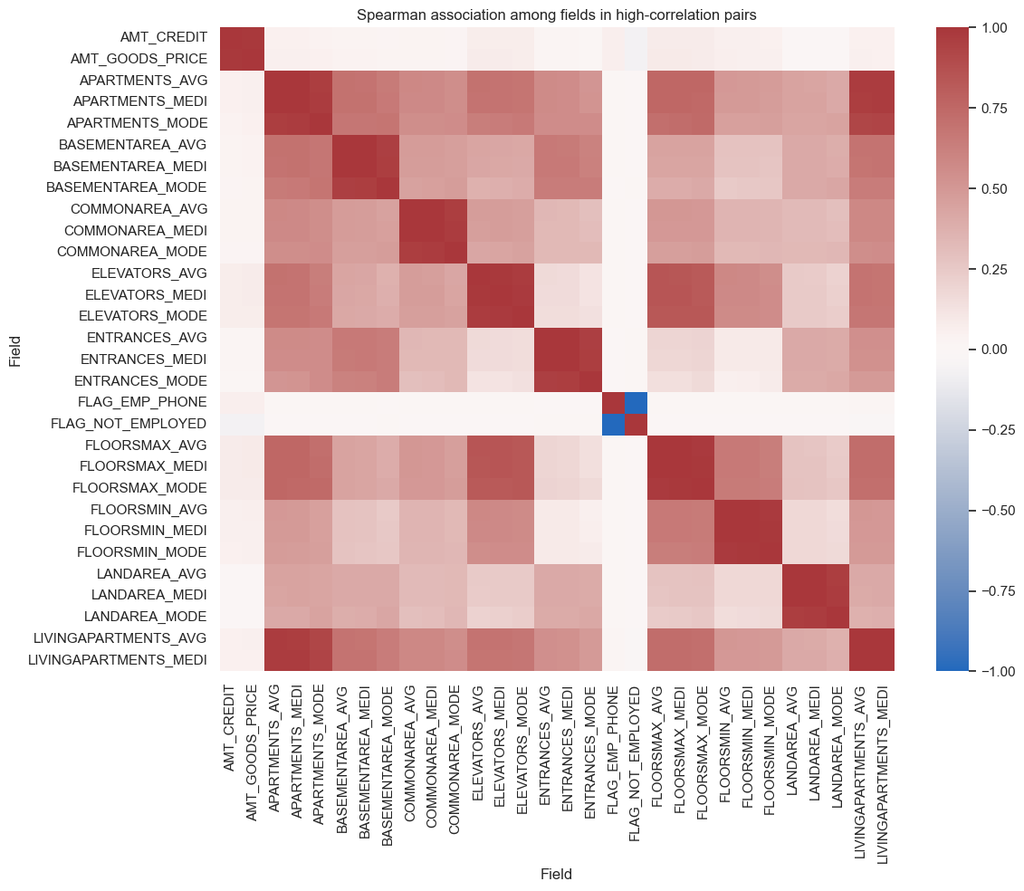

```python
model_cols = [c for c in test.columns if c != "SK_ID_CURR"]
numeric_cols = [c for c in model_cols if pd.api.types.is_numeric_dtype(train[c])]
categorical_cols = [c for c in model_cols if c not in numeric_cols]

constant_cols = [c for c in model_cols if train[c].nunique(dropna=False) <= 1]

signatures = {}
for c in model_cols:
    sig = int(pd.util.hash_pandas_object(train[c], index=False).sum())
    signatures.setdefault((str(train[c].dtype), sig), []).append(c)
exact_duplicate_groups = []
for group in signatures.values():
    if len(group) > 1:
        base = group[0]
        matches = [base] + [c for c in group[1:] if train[base].equals(train[c])]
        if len(matches) > 1:
            exact_duplicate_groups.append(matches)

spearman = train[numeric_cols].corr(method="spearman")

parent = {c: c for c in numeric_cols}
def find(x):
    while parent[x] != x:
        parent[x] = parent[parent[x]]
        x = parent[x]
    return x
def union(a, b):
    ra, rb = find(a), find(b)
    if ra != rb:
        parent[rb] = ra

high_pairs = []
for i, a in enumerate(numeric_cols):
    for b in numeric_cols[i+1:]:
        rho = spearman.loc[a, b]
        if pd.notna(rho) and abs(rho) >= .90:
            union(a, b)
            high_pairs.append((a, b, rho))

components = {}
for c in numeric_cols:
    components.setdefault(find(c), []).append(c)
redundant_components = [members for members in components.values() if len(members) > 1]

def representative(members):
    coverage = {c: train[c].notna().mean() for c in members}
    top = [c for c in members if coverage[c] == max(coverage.values())]
    suffix_penalty = lambda c: (c.endswith("_MODE") or c.endswith("_MEDI"), len(c), c)
    return sorted(top, key=suffix_penalty)[0]

redundancy_rows = []
redundancy_map = {}
for idx, members in enumerate(sorted(redundant_components, key=lambda x: (-len(x), x[0])), 1):
    rep = representative(members)
    for c in members:
        redundancy_map[c] = idx
    redundancy_rows.append({
        "group": idx, "members": ", ".join(sorted(members)), "member_count": len(members),
        "proposed_representative": rep, "representative_coverage": train[rep].notna().mean(),
    })
redundancy_groups = pd.DataFrame(redundancy_rows)

def cramers_v(x, y):
    table = pd.crosstab(x.fillna("<MISSING>"), y.fillna("<MISSING>"))
    if min(table.shape) < 2:
        return np.nan
    chi2 = chi2_contingency(table, correction=False)[0]
    n = table.values.sum()
    phi2 = chi2/n
    r, k = table.shape
    phi2corr = max(0, phi2 - ((k-1)*(r-1))/(n-1))
    rcorr = r - ((r-1)**2)/(n-1)
    kcorr = k - ((k-1)**2)/(n-1)
    return math.sqrt(phi2corr/min(kcorr-1, rcorr-1)) if min(kcorr-1, rcorr-1) > 0 else np.nan

cat_assoc_rows = []
for i, a in enumerate(categorical_cols):
    for b in categorical_cols[i+1:]:
        cat_assoc_rows.append({"field_1": a, "field_2": b, "cramers_v": cramers_v(train[a], train[b])})
categorical_association = pd.DataFrame(cat_assoc_rows).sort_values("cramers_v", ascending=False)

summary = pd.DataFrame([
    {"metric": "candidate columns before grouping", "count": len(model_cols)},
    {"metric": "constant columns", "count": len(constant_cols)},
    {"metric": "exact duplicate groups", "count": len(exact_duplicate_groups)},
    {"metric": "numeric |Spearman rho| >= 0.90 pairs", "count": len(high_pairs)},
    {"metric": "numeric redundancy groups", "count": len(redundant_components)},
    {"metric": "usable groups after constants and numeric grouping", "count": len(model_cols)-len(constant_cols)-sum(len(g)-1 for g in redundant_components)},
])
display(summary)
display(redundancy_groups)
display(categorical_association.head(12))

heat_cols = sorted(set([x for a, b, _ in high_pairs for x in (a, b)]))[:30]
if heat_cols:
    plt.figure(figsize=(12, 10))
    ax = sns.heatmap(spearman.loc[heat_cols, heat_cols], cmap="vlag", center=0, vmin=-1, vmax=1)
    ax.set(title="Spearman association among fields in high-correlation pairs", xlabel="Field", ylabel="Field")
    plt.tight_layout()
    plt.show()
```

This matters for two reasons. A simple logistic model produces unstable coefficients when I feed it three copies of the same measurement. And if I listed ten correlated building columns as ten separate risk factors, I would be overstating how much independent evidence I have.

The count of 85 is the output of one numeric correlation rule, not a count of independent constructs. It does not cover categorical redundancy, and grouping by connected components means two members of the same group are not necessarily correlated with each other above 0.90.

# 6 Q8. Which individual applicant characteristics separate borrowers with repayment difficulty from those without it, and is any one strong enough to stand alone?

|  | variable | type | nonmissing_coverage | heldout_auc | auc_ci_95 | direction | worst_best_rate_ratio | standalone_pass | redundancy_group | headline_eligible |
| --- | --- | --- | --- | --- | --- | --- | --- | --- | --- | --- |
| 0 | EXT_SOURCE_2 | numeric | 0.997854 | 0.653935 | [0.646, 0.662] | higher value/score -> less difficulty | 6.174342 | False |  | True |
| 1 | EXT_SOURCE_3 | numeric | 0.801744 | 0.648970 | [0.641, 0.657] | higher value/score -> less difficulty | 6.197984 | False |  | True |
| 2 | DAYS_BIRTH | numeric | 1.000000 | 0.584857 | [0.577, 0.593] | higher value/score -> more difficulty | 2.359877 | False |  | True |
| 3 | DAYS_EMPLOYED | numeric | 0.819926 | 0.584830 | [0.577, 0.593] | higher value/score -> more difficulty | 2.515098 | False |  | True |
| 4 | EXT_SOURCE_1 | numeric | 0.436188 | 0.579839 | [0.572, 0.588] | higher value/score -> less difficulty | 6.828476 | False |  | True |
| 5 | OCCUPATION_TYPE | categorical/discrete | 0.686547 | 0.574518 | [0.567, 0.582] | higher value/score -> more difficulty | 3.552681 | False |  | True |
| 6 | ORGANIZATION_TYPE | categorical/discrete | 1.000000 | 0.572625 | [0.565, 0.580] | higher value/score -> more difficulty | 3.239417 | False |  | True |
| 7 | NAME_INCOME_TYPE | categorical/discrete | 1.000000 | 0.563294 | [0.556, 0.571] | higher value/score -> more difficulty | 1.780171 | False |  | True |
| 8 | DAYS_LAST_PHONE_CHANGE | numeric | 0.999997 | 0.559276 | [0.552, 0.567] | higher value/score -> more difficulty | 1.836130 | False |  | True |
| 9 | DAYS_ID_PUBLISH | numeric | 1.000000 | 0.556805 | [0.549, 0.564] | higher value/score -> more difficulty | 1.709807 | False |  | True |
| 10 | REGION_RATING_CLIENT | categorical/discrete | 1.000000 | 0.549160 | [0.542, 0.557] | higher value/score -> more difficulty | 2.303385 | False | 15 | True |
| 11 | REGION_RATING_CLIENT_W_CITY | categorical/discrete | 1.000000 | 0.548630 | [0.541, 0.556] | higher value/score -> more difficulty | 2.355426 | False | 15 | True |
| 12 | NAME_EDUCATION_TYPE | categorical/discrete | 1.000000 | 0.545599 | [0.538, 0.553] | higher value/score -> more difficulty | 2.040577 | False |  | True |
| 13 | CODE_GENDER | categorical/discrete | 1.000000 | 0.544474 | [0.537, 0.552] | higher value/score -> more difficulty | 1.448985 | False |  | True |
| 14 | WALLSMATERIAL_MODE | categorical/discrete | 0.491589 | 0.541693 | [0.534, 0.549] | higher value/score -> more difficulty | 2.053871 | False |  | True |
| 15 | REG_CITY_NOT_WORK_CITY | categorical/discrete | 1.000000 | 0.539997 | [0.532, 0.548] | higher value/score -> more difficulty | 1.451077 | False |  | True |
| 16 | EMERGENCYSTATE_MODE | categorical/discrete | 0.526014 | 0.537968 | [0.530, 0.546] | higher value/score -> more difficulty | 1.375304 | False |  | True |
| 17 | DAYS_REGISTRATION | numeric | 1.000000 | 0.537695 | [0.530, 0.545] | higher value/score -> more difficulty | 1.730327 | False |  | True |
| 18 | FLAG_DOCUMENT_3 | categorical/discrete | 1.000000 | 0.535752 | [0.528, 0.543] | higher value/score -> more difficulty | 1.430573 | False |  | True |
| 19 | HOUSETYPE_MODE | categorical/discrete | 0.498236 | 0.535207 | [0.528, 0.543] | higher value/score -> more difficulty | 1.460368 | False |  | True |
| 20 | NAME_FAMILY_STATUS | categorical/discrete | 1.000000 | 0.535085 | [0.527, 0.543] | higher value/score -> more difficulty | 1.707512 | False |  | True |
| 21 | FLAG_NOT_EMPLOYED | categorical/discrete | 1.000000 | 0.534196 | [0.527, 0.542] | higher value/score -> more difficulty | 1.603830 | False | 13 | True |
| 22 | FLAG_EMP_PHONE | categorical/discrete | 1.000000 | 0.534137 | [0.527, 0.542] | higher value/score -> more difficulty | 1.603644 | False | 13 | True |
| 23 | AMT_REQ_CREDIT_BUREAU_QRT | categorical/discrete | 0.864982 | 0.533423 | [0.526, 0.541] | higher value/score -> more difficulty | 1.269173 | False |  | True |
| 24 | AMT_GOODS_PRICE | numeric | 0.999096 | 0.532980 | [0.525, 0.541] | higher value/score -> less difficulty | 2.702339 | False | 12 | True |

```
Stand-alone passes: []
Pre-registered expectation supported: True
```

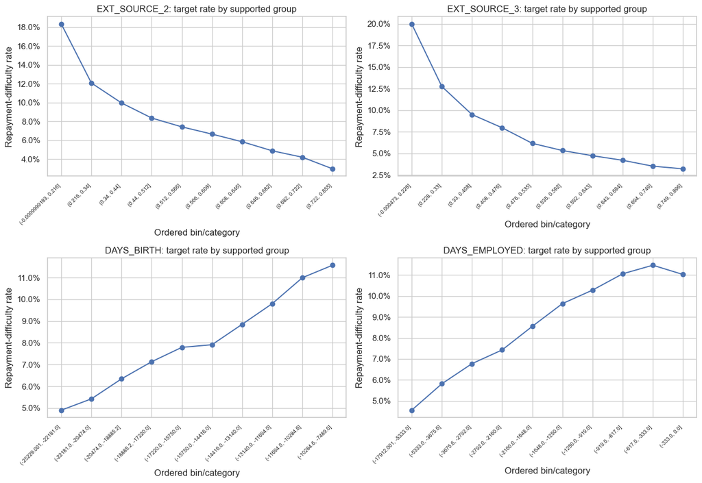

```python
fit_idx, hold_idx = train_test_split(
    np.arange(len(train)), test_size=.25, random_state=RANDOM_STATE, stratify=train["TARGET"]
)
y_fit = train.iloc[fit_idx]["TARGET"].to_numpy()
y_hold = train.iloc[hold_idx]["TARGET"].to_numpy()

def auc_ci(auc, n1, n0):
    q1 = auc/(2-auc)
    q2 = 2*auc*auc/(1+auc)
    se = math.sqrt((auc*(1-auc) + (n1-1)*(q1-auc*auc) + (n0-1)*(q2-auc*auc))/(n1*n0))
    return max(.5, auc-1.96*se), min(1, auc+1.96*se)

def supported_groups(series, minimum=MIN_GROUP):
    s = series.fillna("<MISSING>").astype(str)
    counts = s.value_counts()
    return s.where(s.map(counts) >= minimum, "Other")

def separation_ratio(series, target, numeric):
    work = pd.DataFrame({"x": series, "y": target}).dropna(subset=["x"])
    if numeric:
        try:
            work["group"] = pd.qcut(work["x"], q=10, duplicates="drop")
        except ValueError:
            return np.nan
    else:
        work["group"] = supported_groups(work["x"])
    rates = work.groupby("group", observed=True)["y"].agg(["size", "mean"])
    rates = rates[rates["size"] >= MIN_GROUP]
    if len(rates) < 2 or rates["mean"].min() == 0:
        return np.nan
    return rates["mean"].max()/rates["mean"].min()

univariate_rows = []
for c in model_cols:
    coverage = train[c].notna().mean()
    if coverage < .40:
        continue
    is_numeric = pd.api.types.is_numeric_dtype(train[c]) and train[c].nunique(dropna=True) > 12
    fit_s, hold_s = train.iloc[fit_idx][c], train.iloc[hold_idx][c]
    try:
        if is_numeric:
            fill = fit_s.median()
            fit_score = fit_s.fillna(fill).astype(float)
            hold_score = hold_s.fillna(fill).astype(float)
        else:
            fit_group = supported_groups(fit_s)
            category_means = pd.DataFrame({"g": fit_group, "y": y_fit}).groupby("g")["y"].mean()
            global_mean = y_fit.mean()
            hold_group = hold_s.fillna("<MISSING>").astype(str)
            known = set(category_means.index)
            hold_group = hold_group.where(hold_group.isin(known), "Other")
            fit_score = fit_group.map(category_means).fillna(global_mean).astype(float)
            hold_score = hold_group.map(category_means).fillna(global_mean).astype(float)
        if pd.Series(hold_score).nunique() < 2:
            continue
        raw_auc = roc_auc_score(y_hold, hold_score)
        direction = "higher value/score -> more difficulty" if raw_auc >= .5 else "higher value/score -> less difficulty"
        oriented_auc = max(raw_auc, 1-raw_auc)
        lo, hi = auc_ci(oriented_auc, int(y_hold.sum()), int((1-y_hold).sum()))
        ratio = separation_ratio(train[c], train["TARGET"], is_numeric)
        standalone = oriented_auc >= .70 and pd.notna(ratio) and ratio >= 2.0
        univariate_rows.append({
            "variable": c, "type": "numeric" if is_numeric else "categorical/discrete",
            "nonmissing_coverage": coverage, "heldout_auc": oriented_auc,
            "auc_ci_95": f"[{lo:.3f}, {hi:.3f}]", "direction": direction,
            "worst_best_rate_ratio": ratio, "standalone_pass": standalone,
            "redundancy_group": redundancy_map.get(c, ""),
            "headline_eligible": c not in social_cols,
        })
    except Exception as exc:
        univariate_rows.append({"variable": c, "type": "not scored", "nonmissing_coverage": coverage, "heldout_auc": np.nan, "auc_ci_95": str(exc)[:60]})

univariate = pd.DataFrame(univariate_rows).sort_values("heldout_auc", ascending=False).reset_index(drop=True)
display(univariate.head(25))
print("Stand-alone passes:", univariate.loc[univariate["standalone_pass"] == True, "variable"].tolist())
print("Pre-registered expectation supported:", not univariate["standalone_pass"].fillna(False).any())

top_plot_vars = univariate.loc[(univariate["headline_eligible"] == True) & univariate["heldout_auc"].notna(), "variable"].head(4).tolist()
fig, axes = plt.subplots(2, 2, figsize=(13, 9))
for ax, c in zip(axes.flat, top_plot_vars):
    work = train[[c, "TARGET"]].dropna().copy()
    if pd.api.types.is_numeric_dtype(work[c]) and work[c].nunique() > 12:
        work["bin"] = pd.qcut(work[c], q=10, duplicates="drop")
        rates = work.groupby("bin", observed=True)["TARGET"].agg(["size", "mean"]).reset_index()
        rates = rates[rates["size"] >= MIN_GROUP]
        xlabels = [str(x) for x in rates["bin"]]
    else:
        work["bin"] = supported_groups(work[c])
        rates = work.groupby("bin", observed=True)["TARGET"].agg(["size", "mean"]).reset_index()
        rates = rates[rates["size"] >= MIN_GROUP].sort_values("mean")
        xlabels = rates["bin"].astype(str).tolist()
    ax.plot(range(len(rates)), rates["mean"], marker="o")
    ax.set(title=f"{c}: target rate by supported group", xlabel="Ordered bin/category", ylabel="Repayment-difficulty rate")
    ax.set_xticks(range(len(rates)))
    ax.set_xticklabels(xlabels, rotation=45, ha="right", fontsize=7)
    ax.yaxis.set_major_formatter(plt.FuncFormatter(lambda y, _: f"{y:.1%}"))
for ax in axes.flat[len(top_plot_vars):]:
    ax.axis("off")
plt.tight_layout()
plt.show()
```

Before running this I set the bar for a variable standing on its own: a held-out AUC of at least 0.70, plus a riskiest-group to safest-group default ratio of at least 2.0. Nothing passed. AUC is the chance that if I pick one applicant who defaulted and one who did not, the variable ranks the defaulter as riskier — 0.5 would be a coin flip. My strongest variable, EXT_SOURCE_2, reached 0.654. The strongest one I can actually explain, DAYS_BIRTH, reached 0.585. I predicted this before I ran the analysis and the result matched.

So no single variable met the standard I set, and my recommendation has to be a model combining several weak signals rather than a rule on one column. I should not overstate this: it means nothing passed *this rule*, not that no single fact could ever support any lending decision. The two halves of the rule are also not measured on the same basis — the AUC is held out, the rate ratio is computed on the full training set — so they are not strictly comparable.

# 7 Q9. Do the money variables behave the way an underwriter would expect?

|  | measure | definition | pre_registered_expected_target_direction |
| --- | --- | --- | --- |
| 0 | AMT_INCOME_TOTAL | reported total income | down as value rises |
| 1 | AMT_CREDIT | current application credit amount | no fixed raw-scale direction |
| 2 | AMT_ANNUITY | current application annuity | no fixed raw-scale direction |
| 3 | AMT_GOODS_PRICE | price of financed goods | no fixed raw-scale direction |
| 4 | ANNUITY_TO_INCOME | annuity divided by income; positive denominato... | up as value rises |
| 5 | CREDIT_TO_INCOME | credit divided by income; positive denominator... | up as value rises |
| 6 | CREDIT_TO_GOODS_PRICE | credit divided by goods price; positive denomi... | up as value rises |

|  | raw_income |
| --- | --- |
| count | 3.075070e+05 |
| mean | 1.687977e+05 |
| std | 2.371246e+05 |
| min | 2.565000e+04 |
| 50% | 1.471500e+05 |
| 90% | 2.700000e+05 |
| 99% | 4.725000e+05 |
| 99.9% | 9.000000e+05 |
| max | 1.170000e+08 |

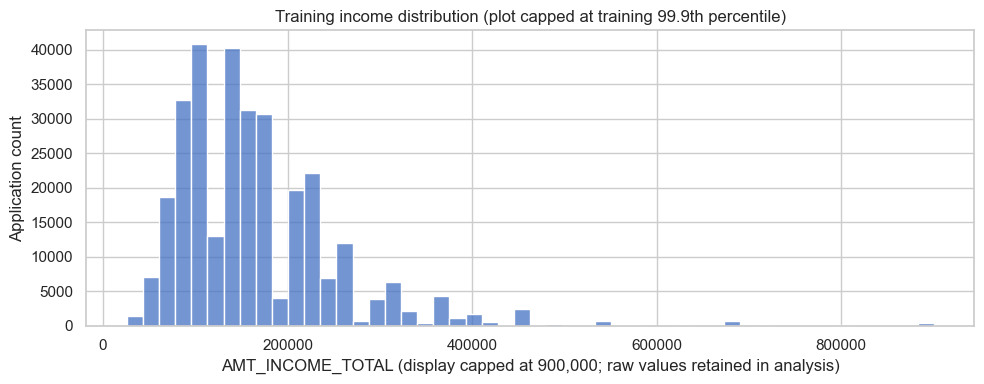

|  | measure | bin_order | bin | n | target_n | target_rate | ci_low | ci_high |
| --- | --- | --- | --- | --- | --- | --- | --- | --- |
| 0 | AMT_INCOME_TOTAL | 1 | (25649.999, 81000.0] | 33391 | 2735 | 0.081908 | 0.079015 | 0.084898 |
| 1 | AMT_INCOME_TOTAL | 2 | (81000.0, 99000.0] | 30280 | 2490 | 0.082232 | 0.079191 | 0.085380 |
| 2 | AMT_INCOME_TOTAL | 3 | (99000.0, 112500.0] | 36907 | 3218 | 0.087192 | 0.084357 | 0.090114 |
| 3 | AMT_INCOME_TOTAL | 4 | (112500.0, 135000.0] | 48848 | 4147 | 0.084896 | 0.082457 | 0.087401 |
| 4 | AMT_INCOME_TOTAL | 5 | (135000.0, 147150.0] | 4333 | 390 | 0.090007 | 0.081845 | 0.098896 |
| 5 | AMT_INCOME_TOTAL | 6 | (147150.0, 162000.0] | 31119 | 2689 | 0.086410 | 0.083339 | 0.089583 |
| 6 | AMT_INCOME_TOTAL | 7 | (162000.0, 180000.0] | 30704 | 2586 | 0.084224 | 0.081169 | 0.087382 |
| 7 | AMT_INCOME_TOTAL | 8 | (180000.0, 225000.0] | 44808 | 3498 | 0.078066 | 0.075618 | 0.080587 |
| 8 | AMT_INCOME_TOTAL | 9 | (225000.0, 270000.0] | 19956 | 1405 | 0.070405 | 0.066937 | 0.074038 |
| 9 | AMT_INCOME_TOTAL | 10 | (270000.0, 117000000.0] | 27161 | 1667 | 0.061375 | 0.058582 | 0.064292 |
| 10 | AMT_CREDIT | 1 | (44999.999, 180000.0] | 33204 | 2232 | 0.067221 | 0.064577 | 0.069965 |
| 11 | AMT_CREDIT | 2 | (180000.0, 254700.0] | 31721 | 2467 | 0.077772 | 0.074875 | 0.080770 |
| 12 | AMT_CREDIT | 3 | (254700.0, 306306.0] | 27390 | 2248 | 0.082074 | 0.078881 | 0.085383 |
| 13 | AMT_CREDIT | 4 | (306306.0, 432000.0] | 30705 | 3081 | 0.100342 | 0.097031 | 0.103753 |
| 14 | AMT_CREDIT | 5 | (432000.0, 513531.0] | 30826 | 2956 | 0.095893 | 0.092656 | 0.099231 |
| 15 | AMT_CREDIT | 6 | (513531.0, 604152.0] | 30725 | 3233 | 0.105224 | 0.101842 | 0.108704 |
| 16 | AMT_CREDIT | 7 | (604152.0, 755190.0] | 34066 | 2908 | 0.085364 | 0.082443 | 0.088378 |
| 17 | AMT_CREDIT | 8 | (755190.0, 900000.0] | 29958 | 2121 | 0.070799 | 0.067949 | 0.073759 |
| 18 | AMT_CREDIT | 9 | (900000.0, 1133748.0] | 28319 | 1949 | 0.068823 | 0.065933 | 0.071830 |
| 19 | AMT_CREDIT | 10 | (1133748.0, 4050000.0] | 30593 | 1630 | 0.053280 | 0.050819 | 0.055853 |
| 20 | AMT_ANNUITY | 1 | (1615.499, 11074.5] | 30880 | 2194 | 0.071049 | 0.068237 | 0.073968 |
| 21 | AMT_ANNUITY | 2 | (11074.5, 14701.5] | 30626 | 2080 | 0.067916 | 0.065152 | 0.070789 |
| 22 | AMT_ANNUITY | 3 | (14701.5, 18189.0] | 30763 | 2608 | 0.084777 | 0.081716 | 0.087942 |
| 23 | AMT_ANNUITY | 4 | (18189.0, 21868.2] | 30729 | 2670 | 0.086889 | 0.083791 | 0.090090 |
| 24 | AMT_ANNUITY | 5 | (21868.2, 24903.0] | 30772 | 2608 | 0.084752 | 0.081692 | 0.087916 |
| 25 | AMT_ANNUITY | 6 | (24903.0, 28062.0] | 30789 | 2804 | 0.091071 | 0.087909 | 0.094336 |
| 26 | AMT_ANNUITY | 7 | (28062.0, 32004.0] | 30690 | 3094 | 0.100815 | 0.097496 | 0.104233 |
| 27 | AMT_ANNUITY | 8 | (32004.0, 37516.5] | 30762 | 2645 | 0.085983 | 0.082901 | 0.089167 |
| 28 | AMT_ANNUITY | 9 | (37516.5, 45954.0] | 30808 | 2348 | 0.076214 | 0.073304 | 0.079230 |
| 29 | AMT_ANNUITY | 10 | (45954.0, 258025.5] | 30676 | 1774 | 0.057830 | 0.055273 | 0.060498 |
| 30 | AMT_GOODS_PRICE | 1 | (40499.999, 180000.0] | 39484 | 2877 | 0.072865 | 0.070343 | 0.075470 |
| 31 | AMT_GOODS_PRICE | 2 | (180000.0, 225000.0] | 31968 | 2848 | 0.089089 | 0.086015 | 0.092261 |
| 32 | AMT_GOODS_PRICE | 3 | (225000.0, 270000.0] | 27990 | 2164 | 0.077313 | 0.074242 | 0.080501 |
| 33 | AMT_GOODS_PRICE | 4 | (270000.0, 373500.0] | 23482 | 2362 | 0.100588 | 0.096806 | 0.104500 |
| 34 | AMT_GOODS_PRICE | 5 | (373500.0, 450000.0] | 35052 | 4652 | 0.132717 | 0.129206 | 0.136309 |
| 35 | AMT_GOODS_PRICE | 6 | (450000.0, 522000.0] | 26475 | 1732 | 0.065420 | 0.062504 | 0.068462 |
| 36 | AMT_GOODS_PRICE | 7 | (522000.0, 675000.0] | 42417 | 3590 | 0.084636 | 0.082024 | 0.087323 |
| 37 | AMT_GOODS_PRICE | 8 | (675000.0, 814500.0] | 18932 | 1060 | 0.055990 | 0.052804 | 0.059356 |
| 38 | AMT_GOODS_PRICE | 9 | (814500.0, 1093500.0] | 30744 | 2012 | 0.065444 | 0.062733 | 0.068263 |
| 39 | AMT_GOODS_PRICE | 10 | (1093500.0, 4050000.0] | 30685 | 1507 | 0.049112 | 0.046750 | 0.051587 |
| 40 | ANNUITY_TO_INCOME | 1 | (-0.000776, 0.08] | 31645 | 2258 | 0.071354 | 0.068570 | 0.074243 |
| 41 | ANNUITY_TO_INCOME | 2 | (0.08, 0.104] | 29855 | 2169 | 0.072651 | 0.069761 | 0.075651 |
| 42 | ANNUITY_TO_INCOME | 3 | (0.104, 0.125] | 30754 | 2404 | 0.078169 | 0.075221 | 0.081222 |
| 43 | ANNUITY_TO_INCOME | 4 | (0.125, 0.144] | 30750 | 2412 | 0.078439 | 0.075486 | 0.081497 |
| 44 | ANNUITY_TO_INCOME | 5 | (0.144, 0.163] | 30756 | 2423 | 0.078781 | 0.075823 | 0.081845 |
| 45 | ANNUITY_TO_INCOME | 6 | (0.163, 0.186] | 30737 | 2574 | 0.083743 | 0.080698 | 0.086892 |
| 46 | ANNUITY_TO_INCOME | 7 | (0.186, 0.212] | 30768 | 2627 | 0.085381 | 0.082310 | 0.088555 |
| 47 | ANNUITY_TO_INCOME | 8 | (0.212, 0.247] | 30754 | 2723 | 0.088541 | 0.085417 | 0.091768 |
| 48 | ANNUITY_TO_INCOME | 9 | (0.247, 0.302] | 30726 | 2716 | 0.088394 | 0.085271 | 0.091620 |
| 49 | ANNUITY_TO_INCOME | 10 | (0.302, 1.876] | 30750 | 2519 | 0.081919 | 0.078905 | 0.085036 |
| 50 | CREDIT_TO_INCOME | 1 | (0.00381, 1.332] | 30759 | 2125 | 0.069085 | 0.066305 | 0.071974 |
| 51 | CREDIT_TO_INCOME | 2 | (1.332, 1.818] | 30779 | 2389 | 0.077618 | 0.074681 | 0.080660 |
| 52 | CREDIT_TO_INCOME | 3 | (1.818, 2.266] | 30728 | 2493 | 0.081131 | 0.078130 | 0.084237 |
| 53 | CREDIT_TO_INCOME | 4 | (2.266, 2.764] | 30772 | 2776 | 0.090212 | 0.087062 | 0.093464 |
| 54 | CREDIT_TO_INCOME | 5 | (2.764, 3.265] | 30724 | 2659 | 0.086545 | 0.083452 | 0.089741 |
| 55 | CREDIT_TO_INCOME | 6 | (3.265, 3.906] | 30743 | 2827 | 0.091956 | 0.088776 | 0.095237 |
| 56 | CREDIT_TO_INCOME | 7 | (3.906, 4.725] | 30752 | 2650 | 0.086173 | 0.083088 | 0.089362 |
| 57 | CREDIT_TO_INCOME | 8 | (4.725, 5.769] | 30751 | 2445 | 0.079510 | 0.076538 | 0.082586 |
| 58 | CREDIT_TO_INCOME | 9 | (5.769, 7.488] | 30815 | 2293 | 0.074412 | 0.071534 | 0.077395 |
| 59 | CREDIT_TO_INCOME | 10 | (7.488, 84.737] | 30684 | 2168 | 0.070656 | 0.067842 | 0.073577 |
| 60 | CREDIT_TO_GOODS_PRICE | 1 | (0.149, 1.0] | 108469 | 7318 | 0.067466 | 0.065989 | 0.068974 |
| 61 | CREDIT_TO_GOODS_PRICE | 2 | (1.0, 1.079] | 14508 | 689 | 0.047491 | 0.044148 | 0.051073 |
| 62 | CREDIT_TO_GOODS_PRICE | 3 | (1.079, 1.119] | 37511 | 2542 | 0.067767 | 0.065267 | 0.070355 |
| 63 | CREDIT_TO_GOODS_PRICE | 4 | (1.119, 1.145] | 28441 | 1918 | 0.067438 | 0.064581 | 0.070411 |
| 64 | CREDIT_TO_GOODS_PRICE | 5 | (1.145, 1.168] | 26132 | 2302 | 0.088091 | 0.084715 | 0.091589 |
| 65 | CREDIT_TO_GOODS_PRICE | 6 | (1.168, 1.211] | 37920 | 3810 | 0.100475 | 0.097489 | 0.103541 |
| 66 | CREDIT_TO_GOODS_PRICE | 7 | (1.211, 1.277] | 24266 | 2405 | 0.099110 | 0.095413 | 0.102933 |
| 67 | CREDIT_TO_GOODS_PRICE | 8 | (1.277, 6.0] | 29982 | 3820 | 0.127410 | 0.123683 | 0.131232 |

|  | measure | expected | observed_bin_rate_direction | spearman_bin_order_vs_rate |
| --- | --- | --- | --- | --- |
| 0 | AMT_INCOME_TOTAL | down as value rises | down | -0.503030 |
| 1 | AMT_CREDIT | no fixed raw-scale direction | down | -0.224242 |
| 2 | AMT_ANNUITY | no fixed raw-scale direction | flat/non-monotonic | 0.066667 |
| 3 | AMT_GOODS_PRICE | no fixed raw-scale direction | down | -0.587879 |
| 4 | ANNUITY_TO_INCOME | up as value rises | up | 0.866667 |
| 5 | CREDIT_TO_INCOME | up as value rises | flat/non-monotonic | -0.042424 |
| 6 | CREDIT_TO_GOODS_PRICE | up as value rises | up | 0.857143 |

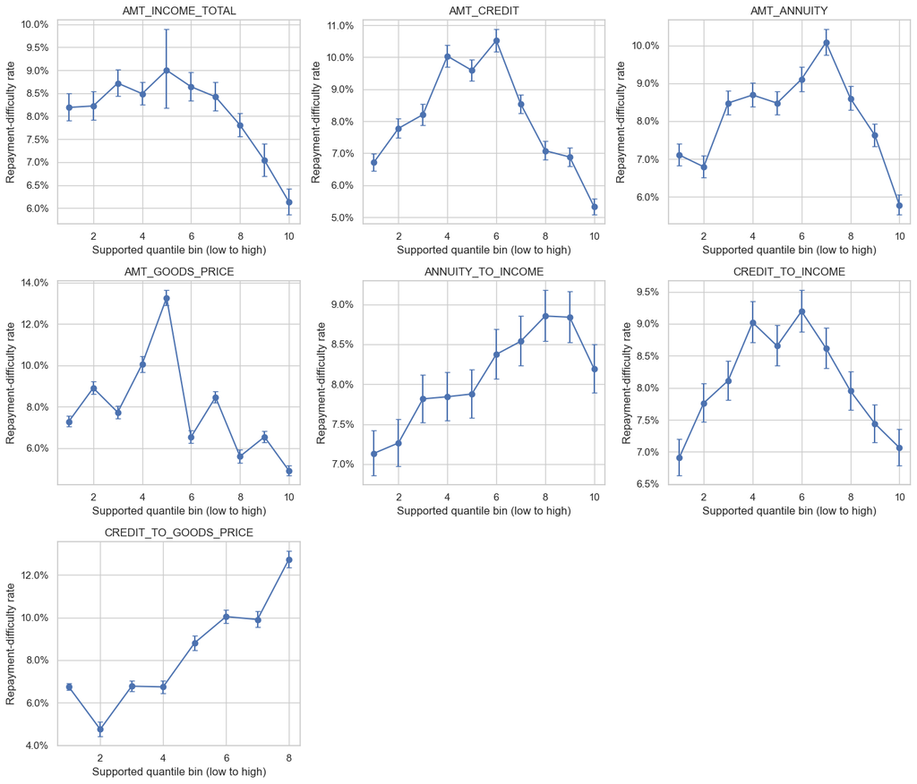

```python
money = train[["TARGET", "AMT_INCOME_TOTAL", "AMT_CREDIT", "AMT_ANNUITY", "AMT_GOODS_PRICE"]].copy()
money["ANNUITY_TO_INCOME"] = np.where(money["AMT_INCOME_TOTAL"] > 0, money["AMT_ANNUITY"] / money["AMT_INCOME_TOTAL"], np.nan)
money["CREDIT_TO_INCOME"] = np.where(money["AMT_INCOME_TOTAL"] > 0, money["AMT_CREDIT"] / money["AMT_INCOME_TOTAL"], np.nan)
money["CREDIT_TO_GOODS_PRICE"] = np.where(money["AMT_GOODS_PRICE"] > 0, money["AMT_CREDIT"] / money["AMT_GOODS_PRICE"], np.nan)

money_definitions = pd.DataFrame([
    {"measure": "AMT_INCOME_TOTAL", "definition": "reported total income", "pre_registered_expected_target_direction": "down as value rises"},
    {"measure": "AMT_CREDIT", "definition": "current application credit amount", "pre_registered_expected_target_direction": "no fixed raw-scale direction"},
    {"measure": "AMT_ANNUITY", "definition": "current application annuity", "pre_registered_expected_target_direction": "no fixed raw-scale direction"},
    {"measure": "AMT_GOODS_PRICE", "definition": "price of financed goods", "pre_registered_expected_target_direction": "no fixed raw-scale direction"},
    {"measure": "ANNUITY_TO_INCOME", "definition": "annuity divided by income; positive denominators only", "pre_registered_expected_target_direction": "up as value rises"},
    {"measure": "CREDIT_TO_INCOME", "definition": "credit divided by income; positive denominators only", "pre_registered_expected_target_direction": "up as value rises"},
    {"measure": "CREDIT_TO_GOODS_PRICE", "definition": "credit divided by goods price; positive denominators only", "pre_registered_expected_target_direction": "up as value rises"},
])
display(money_definitions)
display(train["AMT_INCOME_TOTAL"].describe(percentiles=[.5, .9, .99, .999]).to_frame("raw_income"))

plt.figure(figsize=(10, 4))
income_for_plot = train["AMT_INCOME_TOTAL"].clip(upper=income_plot_cap)
ax = sns.histplot(income_for_plot, bins=50, color="#4472C4")
ax.set(
    title="Training income distribution (plot capped at training 99.9th percentile)",
    xlabel=f"AMT_INCOME_TOTAL (display capped at {income_plot_cap:,.0f}; raw values retained in analysis)",
    ylabel="Application count",
)
plt.tight_layout()
plt.show()

money_bin_rows = []
observation_rows = []
for c in money_definitions["measure"]:
    work = money[[c, "TARGET"]].dropna().copy()
    work["bin"] = pd.qcut(work[c], q=10, duplicates="drop")
    grouped = work.groupby("bin", observed=True)["TARGET"].agg(["size", "sum", "mean"]).reset_index()
    grouped = grouped[grouped["size"] >= MIN_GROUP].copy()
    grouped["ci_low"], grouped["ci_high"] = zip(*[wilson(s, n) for s, n in zip(grouped["sum"], grouped["size"])])
    grouped["measure"] = c
    grouped["bin_order"] = np.arange(1, len(grouped)+1)
    money_bin_rows.append(grouped.rename(columns={"size": "n", "sum": "target_n", "mean": "target_rate"}))
    rho = grouped["bin_order"].corr(grouped["mean"], method="spearman")
    observed = "up" if rho > .2 else "down" if rho < -.2 else "flat/non-monotonic"
    expected = money_definitions.set_index("measure").loc[c, "pre_registered_expected_target_direction"]
    observation_rows.append({"measure": c, "expected": expected, "observed_bin_rate_direction": observed, "spearman_bin_order_vs_rate": rho})
money_bins = pd.concat(money_bin_rows, ignore_index=True)
money_observed = pd.DataFrame(observation_rows)
display(money_bins[["measure", "bin_order", "bin", "n", "target_n", "target_rate", "ci_low", "ci_high"]])
display(money_observed)

fig, axes = plt.subplots(3, 3, figsize=(14, 12))
for ax, c in zip(axes.flat, money_definitions["measure"]):
    p = money_bins[money_bins["measure"] == c]
    ax.errorbar(p["bin_order"], p["target_rate"], yerr=[p["target_rate"]-p["ci_low"], p["ci_high"]-p["target_rate"]], marker="o", capsize=3)
    ax.set(title=f"{c}", xlabel="Supported quantile bin (low to high)", ylabel="Repayment-difficulty rate")
    ax.yaxis.set_major_formatter(plt.FuncFormatter(lambda y, _: f"{y:.1%}"))
for ax in axes.flat[len(money_definitions):]:
    ax.axis("off")
plt.tight_layout()
plt.show()
```

I wrote down what I expected before I looked: default rising as both annuity-to-income and credit-to-income went up. The rank correlations appeared to confirm it for annuity-to-income (0.87) and reject it for credit-to-income (−0.04). Looking at the binned rates directly shows that reading was wrong.

Credit-to-income is not flat. Its default rate climbs from 6.91% in the lowest decile to 9.20% in the sixth, then falls back to 7.07% in the highest. It is an inverted U. The rank correlation sits near zero because the rise and the fall cancel out, not because there is no relationship — a monotonic statistic reports nothing when the shape is symmetric and non-monotonic.

The same shape appears more strongly in the raw loan amount. AMT_CREDIT runs from 6.72% up to 10.52% in the sixth decile and down to 5.33% in the tenth. Annuity-to-income is closer to monotonic but also turns at the top, peaking at 8.85% in the eighth decile and easing to 8.19% in the tenth.

My original conclusion — that payment burden matters and loan size does not — is therefore not supported. What the bins show is that risk peaks in the middle of the loan-size distribution and falls at both ends. The low end is small loans with little exposure; the high end is large loans that were probably approved only for stronger applicants. Everyone in this data was already approved, so this is a pattern inside a screened population, not a causal statement about lending.

The practical consequence is for the modeling stage. A logistic baseline assuming a straight-line relationship will miss this shape entirely and report these variables as uninformative — which is exactly what my rank correlation did. They need binning, splines, or a model that handles non-monotonic relationships. That is a more useful finding than the one I expected, and I only reached it by looking at the bins instead of trusting a single summary statistic.

# 8 Q10. Which predictors survive all three screens: predictive value, availability, and verifiability?

```python
def verifiability_tier(c):
    if c.startswith("EXT_SOURCE_") or c in social_cols:
        return "C"
    tier_a_exact = {"DAYS_BIRTH", "DAYS_EMPLOYED", "FLAG_NOT_EMPLOYED", "NAME_EDUCATION_TYPE", "NAME_FAMILY_STATUS", "NAME_HOUSING_TYPE", "FLAG_OWN_CAR", "OWN_CAR_AGE", "FLAG_OWN_REALTY", "OCCUPATION_TYPE", "ORGANIZATION_TYPE"}
    if c in tier_a_exact or c.startswith("AMT_") or c.startswith("NAME_INCOME") or c.startswith("AMT_REQ_CREDIT_BUREAU_"):
        return "A"
    return "B"

def governance_flag(c):
    flags = []
    if c == "CODE_GENDER": flags.append("sex/protected-attribute review")
    if c == "DAYS_BIRTH": flags.append("age review")
    if c in {"NAME_FAMILY_STATUS", "CNT_CHILDREN", "CNT_FAM_MEMBERS"}: flags.append("family-status review")
    if "REGION" in c or c in {"LIVE_CITY_NOT_WORK_CITY", "REG_CITY_NOT_WORK_CITY", "REG_CITY_NOT_LIVE_CITY"}: flags.append("geographic-proxy review")
    if c.startswith("EXT_SOURCE_"): flags.append("opaque-score review")
    if c in social_cols: flags.append("privacy/proxy review")
    return "; ".join(flags) or "none identified in this screen"

miss_lookup = missingness.set_index("field")
uni_lookup = univariate.set_index("variable")
level_mismatch_fields = set(level_mismatch["field"]) if not level_mismatch.empty else set()
anomaly_fields = {"DAYS_EMPLOYED", "CODE_GENDER", "REGION_RATING_CLIENT_W_CITY", "AMT_INCOME_TOTAL", *social_cols}

grouped_out = set()
score_rows = []
for c in model_cols:
    group_id = redundancy_map.get(c)
    if group_id:
        members = next(g for g in redundant_components if c in g)
        rep = representative(members)
        if c != rep or group_id in grouped_out:
            continue
        grouped_out.add(group_id)
        group_label = ", ".join(sorted(members))
    else:
        rep, group_label = c, c
    coverage = 1 - miss_lookup.loc[rep, "train_missing_share"] if rep in miss_lookup.index else train[rep].notna().mean()
    auc = uni_lookup.loc[rep, "heldout_auc"] if rep in uni_lookup.index else np.nan
    ratio = uni_lookup.loc[rep, "worst_best_rate_ratio"] if rep in uni_lookup.index else np.nan
    # "Meaningful signal" is a lower bar than standing alone (AUC 0.70 + 2.0x decile ratio):
    # enough separation to be worth carrying alongside other predictors, not on its own.
    # Set at 0.55 after seeing the univariate ranking, so this is a judgment call rather
    # than a pre-registered threshold, and the notebook says so.
    MEANINGFUL_AUC = 0.55
    meaningful_signal = bool(pd.notna(auc) and auc >= MEANINGFUL_AUC)
    tier = verifiability_tier(rep)
    if tier == "C" or coverage < .50:
        disposition = "Fail"
    elif tier == "A" and coverage >= .80 and meaningful_signal:
        disposition = "Pass"
    else:
        disposition = "Review"
    score_rows.append({
        "feature_group": group_label, "representative": rep, "heldout_auc": auc,
        "worst_best_rate_ratio": ratio, "meets_meaningful_signal": meaningful_signal,
        "coverage": coverage, "train_test_compatibility": "level review" if rep in level_mismatch_fields else "observed compatible",
        "anomaly_burden": "registered" if rep in anomaly_fields else "none registered",
        "temporal_status": "review" if rep.startswith("EXT_SOURCE_") else "application/pre-application",
        "redundancy": f"group {group_id}" if group_id else "not grouped",
        "verifiability_tier": tier, "governance_flag": governance_flag(rep), "disposition": disposition,
    })

feature_scorecard = pd.DataFrame(score_rows).sort_values(["disposition", "heldout_auc"], ascending=[True, False]).reset_index(drop=True)
display(feature_scorecard.head(40))
survivors = feature_scorecard[feature_scorecard["disposition"].isin(["Pass", "Review"])].sort_values("heldout_auc", ascending=False)
display(survivors[["representative", "heldout_auc", "coverage", "verifiability_tier", "governance_flag", "disposition"]].head(20))
display(feature_scorecard[feature_scorecard["verifiability_tier"] == "C"][["representative", "heldout_auc", "coverage", "disposition"]].sort_values("heldout_auc", ascending=False))
print("Disposition counts:")
display(feature_scorecard["disposition"].value_counts().rename_axis("disposition").to_frame("feature_groups"))
```

|  | feature_group | representative | heldout_auc | worst_best_rate_ratio | meets_meaningful_signal | coverage | train_test_compatibility | anomaly_burden | temporal_status | redundancy | verifiability_tier | governance_flag | disposition |
| --- | --- | --- | --- | --- | --- | --- | --- | --- | --- | --- | --- | --- | --- |
| 0 | EXT_SOURCE_2 | EXT_SOURCE_2 | 0.653935 | 6.174342 | True | 0.997854 | observed compatible | none registered | review | not grouped | C | opaque-score review | Fail |
| 1 | EXT_SOURCE_3 | EXT_SOURCE_3 | 0.648970 | 6.197984 | True | 0.801744 | observed compatible | none registered | review | not grouped | C | opaque-score review | Fail |
| 2 | EXT_SOURCE_1 | EXT_SOURCE_1 | 0.579839 | 6.828476 | True | 0.436188 | observed compatible | none registered | review | not grouped | C | opaque-score review | Fail |
| 3 | WALLSMATERIAL_MODE | WALLSMATERIAL_MODE | 0.541693 | 2.053871 | False | 0.491589 | observed compatible | none registered | application/pre-application | not grouped | B | none identified in this screen | Fail |
| 4 | HOUSETYPE_MODE | HOUSETYPE_MODE | 0.535207 | 1.460368 | False | 0.498236 | observed compatible | none registered | application/pre-application | not grouped | B | none identified in this screen | Fail |
| 5 | ELEVATORS_AVG, ELEVATORS_MEDI, ELEVATORS_MODE | ELEVATORS_AVG | 0.529065 | 1.473965 | False | 0.467037 | observed compatible | none registered | application/pre-application | group 5 | B | none identified in this screen | Fail |
| 6 | DEF_30_CNT_SOCIAL_CIRCLE | DEF_30_CNT_SOCIAL_CIRCLE | 0.515276 | 1.650665 | False | 0.996680 | observed compatible | registered | application/pre-application | not grouped | C | privacy/proxy review | Fail |
| 7 | BASEMENTAREA_AVG, BASEMENTAREA_MEDI, BASEMENTA... | BASEMENTAREA_AVG | 0.513194 | 1.369472 | False | 0.414836 | observed compatible | none registered | application/pre-application | group 3 | B | none identified in this screen | Fail |
| 8 | DEF_60_CNT_SOCIAL_CIRCLE | DEF_60_CNT_SOCIAL_CIRCLE | 0.512437 | 1.550133 | False | 0.996680 | observed compatible | registered | application/pre-application | not grouped | C | privacy/proxy review | Fail |
| 9 | OBS_30_CNT_SOCIAL_CIRCLE, OBS_60_CNT_SOCIAL_CI... | OBS_30_CNT_SOCIAL_CIRCLE | 0.511064 | 1.114169 | False | 0.996680 | observed compatible | registered | application/pre-application | group 14 | C | privacy/proxy review | Fail |
| 10 | ENTRANCES_AVG, ENTRANCES_MEDI, ENTRANCES_MODE | ENTRANCES_AVG | 0.509478 | 1.341984 | False | 0.496509 | observed compatible | none registered | application/pre-application | group 6 | B | none identified in this screen | Fail |
| 11 | NONLIVINGAREA_AVG, NONLIVINGAREA_MEDI, NONLIVI... | NONLIVINGAREA_AVG | 0.509126 | 1.228696 | False | 0.448208 | observed compatible | none registered | application/pre-application | group 11 | B | none identified in this screen | Fail |
| 12 | LANDAREA_AVG, LANDAREA_MEDI, LANDAREA_MODE | LANDAREA_AVG | 0.505576 | 1.247265 | False | 0.406231 | observed compatible | none registered | application/pre-application | group 9 | B | none identified in this screen | Fail |
| 13 | OWN_CAR_AGE | OWN_CAR_AGE | NaN | NaN | False | 0.340090 | observed compatible | none registered | application/pre-application | not grouped | A | none identified in this screen | Fail |
| 14 | COMMONAREA_AVG, COMMONAREA_MEDI, COMMONAREA_MODE | COMMONAREA_AVG | NaN | NaN | False | 0.301278 | observed compatible | none registered | application/pre-application | group 4 | B | none identified in this screen | Fail |
| 15 | FLOORSMIN_AVG, FLOORSMIN_MEDI, FLOORSMIN_MODE | FLOORSMIN_AVG | NaN | NaN | False | 0.321511 | observed compatible | none registered | application/pre-application | group 8 | B | none identified in this screen | Fail |
| 16 | NONLIVINGAPARTMENTS_AVG, NONLIVINGAPARTMENTS_M... | NONLIVINGAPARTMENTS_AVG | NaN | NaN | False | 0.305668 | observed compatible | none registered | application/pre-application | group 10 | B | none identified in this screen | Fail |
| 17 | FONDKAPREMONT_MODE | FONDKAPREMONT_MODE | NaN | NaN | False | 0.316136 | observed compatible | none registered | application/pre-application | not grouped | B | none identified in this screen | Fail |
| 18 | DAYS_BIRTH | DAYS_BIRTH | 0.584857 | 2.359877 | True | 1.000000 | observed compatible | none registered | application/pre-application | not grouped | A | age review | Pass |
| 19 | DAYS_EMPLOYED | DAYS_EMPLOYED | 0.584830 | 2.515098 | True | 0.819926 | observed compatible | registered | application/pre-application | not grouped | A | none identified in this screen | Pass |
| 20 | ORGANIZATION_TYPE | ORGANIZATION_TYPE | 0.572625 | 3.239417 | True | 1.000000 | observed compatible | none registered | application/pre-application | not grouped | A | none identified in this screen | Pass |
| 21 | NAME_INCOME_TYPE | NAME_INCOME_TYPE | 0.563294 | 1.780171 | True | 1.000000 | level review | none registered | application/pre-application | not grouped | A | none identified in this screen | Pass |
| 22 | OCCUPATION_TYPE | OCCUPATION_TYPE | 0.574518 | 3.552681 | True | 0.686547 | observed compatible | none registered | application/pre-application | not grouped | A | none identified in this screen | Review |
| 23 | DAYS_LAST_PHONE_CHANGE | DAYS_LAST_PHONE_CHANGE | 0.559276 | 1.836130 | True | 0.999997 | observed compatible | none registered | application/pre-application | not grouped | B | none identified in this screen | Review |
| 24 | DAYS_ID_PUBLISH | DAYS_ID_PUBLISH | 0.556805 | 1.709807 | True | 1.000000 | observed compatible | none registered | application/pre-application | not grouped | B | none identified in this screen | Review |
| 25 | REGION_RATING_CLIENT, REGION_RATING_CLIENT_W_CITY | REGION_RATING_CLIENT | 0.549160 | 2.303385 | False | 1.000000 | observed compatible | none registered | application/pre-application | group 15 | B | geographic-proxy review | Review |
| 26 | NAME_EDUCATION_TYPE | NAME_EDUCATION_TYPE | 0.545599 | 2.040577 | False | 1.000000 | observed compatible | none registered | application/pre-application | not grouped | A | none identified in this screen | Review |
| 27 | CODE_GENDER | CODE_GENDER | 0.544474 | 1.448985 | False | 1.000000 | level review | registered | application/pre-application | not grouped | B | sex/protected-attribute review | Review |
| 28 | REG_CITY_NOT_WORK_CITY | REG_CITY_NOT_WORK_CITY | 0.539997 | 1.451077 | False | 1.000000 | observed compatible | none registered | application/pre-application | not grouped | B | geographic-proxy review | Review |
| 29 | EMERGENCYSTATE_MODE | EMERGENCYSTATE_MODE | 0.537968 | 1.375304 | False | 0.526014 | observed compatible | none registered | application/pre-application | not grouped | B | none identified in this screen | Review |
| 30 | DAYS_REGISTRATION | DAYS_REGISTRATION | 0.537695 | 1.730327 | False | 1.000000 | observed compatible | none registered | application/pre-application | not grouped | B | none identified in this screen | Review |
| 31 | FLAG_DOCUMENT_3 | FLAG_DOCUMENT_3 | 0.535752 | 1.430573 | False | 1.000000 | observed compatible | none registered | application/pre-application | not grouped | B | none identified in this screen | Review |
| 32 | NAME_FAMILY_STATUS | NAME_FAMILY_STATUS | 0.535085 | 1.707512 | False | 1.000000 | level review | none registered | application/pre-application | not grouped | A | family-status review | Review |
| 33 | FLAG_EMP_PHONE, FLAG_NOT_EMPLOYED | FLAG_EMP_PHONE | 0.534137 | 1.603644 | False | 1.000000 | observed compatible | none registered | application/pre-application | group 13 | B | none identified in this screen | Review |
| 34 | AMT_REQ_CREDIT_BUREAU_QRT | AMT_REQ_CREDIT_BUREAU_QRT | 0.533423 | 1.269173 | False | 0.864982 | observed compatible | none registered | application/pre-application | not grouped | A | none identified in this screen | Review |
| 35 | REGION_POPULATION_RELATIVE | REGION_POPULATION_RELATIVE | 0.532859 | 2.117063 | False | 1.000000 | observed compatible | none registered | application/pre-application | not grouped | B | geographic-proxy review | Review |
| 36 | FLOORSMAX_AVG, FLOORSMAX_MEDI, FLOORSMAX_MODE | FLOORSMAX_AVG | 0.529033 | 1.891421 | False | 0.502389 | observed compatible | none registered | application/pre-application | group 7 | B | none identified in this screen | Review |
| 37 | LIVE_CITY_NOT_WORK_CITY | LIVE_CITY_NOT_WORK_CITY | 0.524002 | 1.301349 | False | 1.000000 | observed compatible | none registered | application/pre-application | not grouped | B | geographic-proxy review | Review |
| 38 | AMT_REQ_CREDIT_BUREAU_DAY | AMT_REQ_CREDIT_BUREAU_DAY | 0.522905 | 1.254907 | False | 0.864982 | observed compatible | none registered | application/pre-application | not grouped | A | none identified in this screen | Review |
| 39 | AMT_REQ_CREDIT_BUREAU_HOUR | AMT_REQ_CREDIT_BUREAU_HOUR | 0.521856 | 1.038273 | False | 0.864982 | observed compatible | none registered | application/pre-application | not grouped | A | none identified in this screen | Review |

|  | representative | heldout_auc | coverage | verifiability_tier | governance_flag | disposition |
| --- | --- | --- | --- | --- | --- | --- |
| 18 | DAYS_BIRTH | 0.584857 | 1.000000 | A | age review | Pass |
| 19 | DAYS_EMPLOYED | 0.584830 | 0.819926 | A | none identified in this screen | Pass |
| 22 | OCCUPATION_TYPE | 0.574518 | 0.686547 | A | none identified in this screen | Review |
| 20 | ORGANIZATION_TYPE | 0.572625 | 1.000000 | A | none identified in this screen | Pass |
| 21 | NAME_INCOME_TYPE | 0.563294 | 1.000000 | A | none identified in this screen | Pass |
| 23 | DAYS_LAST_PHONE_CHANGE | 0.559276 | 0.999997 | B | none identified in this screen | Review |
| 24 | DAYS_ID_PUBLISH | 0.556805 | 1.000000 | B | none identified in this screen | Review |
| 25 | REGION_RATING_CLIENT | 0.549160 | 1.000000 | B | geographic-proxy review | Review |
| 26 | NAME_EDUCATION_TYPE | 0.545599 | 1.000000 | A | none identified in this screen | Review |
| 27 | CODE_GENDER | 0.544474 | 1.000000 | B | sex/protected-attribute review | Review |
| 28 | REG_CITY_NOT_WORK_CITY | 0.539997 | 1.000000 | B | geographic-proxy review | Review |
| 29 | EMERGENCYSTATE_MODE | 0.537968 | 0.526014 | B | none identified in this screen | Review |
| 30 | DAYS_REGISTRATION | 0.537695 | 1.000000 | B | none identified in this screen | Review |
| 31 | FLAG_DOCUMENT_3 | 0.535752 | 1.000000 | B | none identified in this screen | Review |
| 32 | NAME_FAMILY_STATUS | 0.535085 | 1.000000 | A | family-status review | Review |
| 33 | FLAG_EMP_PHONE | 0.534137 | 1.000000 | B | none identified in this screen | Review |
| 34 | AMT_REQ_CREDIT_BUREAU_QRT | 0.533423 | 0.864982 | A | none identified in this screen | Review |
| 35 | REGION_POPULATION_RELATIVE | 0.532859 | 1.000000 | B | geographic-proxy review | Review |
| 36 | FLOORSMAX_AVG | 0.529033 | 0.502389 | B | none identified in this screen | Review |
| 37 | LIVE_CITY_NOT_WORK_CITY | 0.524002 | 1.000000 | B | geographic-proxy review | Review |

|  | representative | heldout_auc | coverage | disposition |
| --- | --- | --- | --- | --- |
| 0 | EXT_SOURCE_2 | 0.653935 | 0.997854 | Fail |
| 1 | EXT_SOURCE_3 | 0.648970 | 0.801744 | Fail |
| 2 | EXT_SOURCE_1 | 0.579839 | 0.436188 | Fail |
| 6 | DEF_30_CNT_SOCIAL_CIRCLE | 0.515276 | 0.996680 | Fail |
| 8 | DEF_60_CNT_SOCIAL_CIRCLE | 0.512437 | 0.996680 | Fail |
| 9 | OBS_30_CNT_SOCIAL_CIRCLE | 0.511064 | 0.996680 | Fail |

```
Disposition counts:
```

| disposition | feature_groups |
| --- | --- |
| Review | 63 |
| Fail | 18 |
| Pass | 4 |

Four variables passed all three tests: DAYS_BIRTH, DAYS_EMPLOYED, ORGANIZATION_TYPE and NAME_INCOME_TYPE. Sixty-three are in Review and eighteen failed. None of the four is strong on its own — the best reaches an AUC of 0.585.

The strongest variable I exclude, EXT_SOURCE_2, reaches 0.654 against 0.585 for my best passing variable. I should be careful about what that comparison means. These are two separate single-variable AUCs, not a measure of what EXT_SOURCE would add on top of the four I keep. Measuring the real cost of the exclusion needs a model fitted with and without them, which belongs to the modeling stage. What I can say now is that the strongest excluded variable outranks the strongest retained one, and that quantifying the trade-off properly is a next step.

Three cautions. I set the 0.55 signal threshold after seeing the univariate results, not before, so it is a judgment call and not a pre-registered rule. The verifiability tiers are assigned from the data dictionary, not measured — I have no evidence about how any of these fields is verified in practice, and an opaque EXT_SOURCE score might well be verifiable through a vendor contract I cannot see. And passing this screen means a variable is predictive and verifiable, not that it is legally permissible: DAYS_BIRTH measures age and CODE_GENDER measures sex, both protected characteristics under the Equal Credit Opportunity Act, and both would need compliance review before use.

# 9 Q11. Does the repayment-difficulty rate vary enough across major customer segments to threaten the stability promised by the BPS?

|  | segment | level | n | share | target_n | target_rate | ci_low | ci_high | absolute_difference | relative_to_overall | status |
| --- | --- | --- | --- | --- | --- | --- | --- | --- | --- | --- | --- |
| 1 | CODE_GENDER | M | 105059 | 0.341648 | 10655 | 0.101419 | 0.099608 | 0.103259 | 0.020689 | 1.256279 | Note |
| 0 | CODE_GENDER | F | 202448 | 0.658352 | 14170 | 0.069993 | 0.068890 | 0.071113 | -0.010737 | 0.867006 | No flag |
| 4 | NAME_EDUCATION_TYPE | Lower secondary | 3816 | 0.012409 | 417 | 0.109277 | 0.099768 | 0.119571 | 0.028547 | 1.353610 | Note |
| 6 | NAME_EDUCATION_TYPE | Secondary / secondary special | 218389 | 0.710192 | 19524 | 0.089400 | 0.088211 | 0.090604 | 0.008670 | 1.107398 | No flag |
| 3 | NAME_EDUCATION_TYPE | Incomplete higher | 10276 | 0.033417 | 872 | 0.084858 | 0.079624 | 0.090402 | 0.004128 | 1.051134 | No flag |
| 2 | NAME_EDUCATION_TYPE | Higher education | 74862 | 0.243448 | 4009 | 0.053552 | 0.051962 | 0.055188 | -0.027178 | 0.663346 | Note |
| 5 | NAME_EDUCATION_TYPE | Other | 164 | 0.000533 | 3 | 0.018293 | 0.006240 | 0.052396 | -0.062437 | 0.226591 | No flag |
| 19 | NAME_HOUSING_TYPE | Rented apartment | 4881 | 0.015873 | 601 | 0.123131 | 0.114207 | 0.132646 | 0.042401 | 1.525216 | Note |
| 20 | NAME_HOUSING_TYPE | With parents | 14840 | 0.048259 | 1736 | 0.116981 | 0.111909 | 0.122252 | 0.036251 | 1.449044 | Note |
| 17 | NAME_HOUSING_TYPE | Municipal apartment | 11182 | 0.036363 | 955 | 0.085405 | 0.080366 | 0.090729 | 0.004675 | 1.057912 | No flag |
| 15 | NAME_HOUSING_TYPE | Co-op apartment | 1122 | 0.003649 | 89 | 0.079323 | 0.064907 | 0.096609 | -0.001407 | 0.982569 | No flag |
| 16 | NAME_HOUSING_TYPE | House / apartment | 272865 | 0.887346 | 21272 | 0.077958 | 0.076958 | 0.078970 | -0.002772 | 0.965664 | No flag |
| 18 | NAME_HOUSING_TYPE | Office apartment | 2617 | 0.008510 | 172 | 0.065724 | 0.056852 | 0.075869 | -0.015006 | 0.814124 | No flag |
| 8 | NAME_INCOME_TYPE | Other | 55 | 0.000179 | 10 | 0.181818 | 0.101876 | 0.303307 | 0.101088 | 2.252180 | No flag |
| 11 | NAME_INCOME_TYPE | Working | 158771 | 0.516317 | 15224 | 0.095887 | 0.094448 | 0.097345 | 0.015157 | 1.187745 | No flag |
| 7 | NAME_INCOME_TYPE | Commercial associate | 71616 | 0.232892 | 5360 | 0.074844 | 0.072939 | 0.076794 | -0.005886 | 0.927087 | No flag |
| 10 | NAME_INCOME_TYPE | State servant | 21703 | 0.070577 | 1249 | 0.057550 | 0.054529 | 0.060727 | -0.023180 | 0.712867 | Note |
| 9 | NAME_INCOME_TYPE | Pensioner | 55362 | 0.180035 | 2982 | 0.053864 | 0.052014 | 0.055775 | -0.026866 | 0.667209 | Note |
| 14 | REGION_RATING_CLIENT_W_CITY | 3 | 43859 | 0.142628 | 5001 | 0.114024 | 0.111084 | 0.117033 | 0.033295 | 1.412420 | Note |
| 13 | REGION_RATING_CLIENT_W_CITY | 2 | 229481 | 0.746263 | 18170 | 0.079179 | 0.078081 | 0.080291 | -0.001551 | 0.980785 | No flag |
| 12 | REGION_RATING_CLIENT_W_CITY | 1 | 34167 | 0.111110 | 1654 | 0.048409 | 0.046184 | 0.050736 | -0.032321 | 0.599645 | Note |

|  | segment | level | train_share | test_share | test_minus_train_pp |
| --- | --- | --- | --- | --- | --- |
| 0 | CODE_GENDER | F | 0.658352 | 0.670400 | 1.204797 |
| 1 | CODE_GENDER | M | 0.341648 | 0.329600 | -1.204797 |
| 2 | NAME_EDUCATION_TYPE | Higher education | 0.243448 | 0.256770 | 1.332195 |
| 3 | NAME_EDUCATION_TYPE | Incomplete higher | 0.033417 | 0.035368 | 0.195133 |
| 5 | NAME_EDUCATION_TYPE | Other | 0.000533 | 0.000841 | 0.030781 |
| 4 | NAME_EDUCATION_TYPE | Lower secondary | 0.012409 | 0.009745 | -0.266468 |
| 6 | NAME_EDUCATION_TYPE | Secondary / secondary special | 0.710192 | 0.697276 | -1.291640 |
| 16 | NAME_HOUSING_TYPE | House / apartment | 0.887346 | 0.895392 | 0.804660 |
| 18 | NAME_HOUSING_TYPE | Office apartment | 0.008510 | 0.008350 | -0.016063 |
| 15 | NAME_HOUSING_TYPE | Co-op apartment | 0.003649 | 0.002523 | -0.112531 |
| 19 | NAME_HOUSING_TYPE | Rented apartment | 0.015873 | 0.014730 | -0.114279 |
| 20 | NAME_HOUSING_TYPE | With parents | 0.048259 | 0.045831 | -0.242778 |
| 17 | NAME_HOUSING_TYPE | Municipal apartment | 0.036363 | 0.033173 | -0.319009 |
| 9 | NAME_INCOME_TYPE | Pensioner | 0.180035 | 0.190239 | 1.020387 |
| 10 | NAME_INCOME_TYPE | State servant | 0.070577 | 0.072460 | 0.188295 |
| 7 | NAME_INCOME_TYPE | Commercial associate | 0.232892 | 0.233916 | 0.102371 |
| 8 | NAME_INCOME_TYPE | Other | 0.000179 | 0.000082 | -0.009680 |
| 11 | NAME_INCOME_TYPE | Working | 0.516317 | 0.503303 | -1.301373 |
| 12 | REGION_RATING_CLIENT_W_CITY | 1 | 0.111110 | 0.126682 | 1.557259 |
| 14 | REGION_RATING_CLIENT_W_CITY | 3 | 0.142628 | 0.139340 | -0.328742 |
| 13 | REGION_RATING_CLIENT_W_CITY | 2 | 0.746263 | 0.733978 | -1.228517 |

|  | segment | level | predictor | n_nonmissing | signed_auc | ci_low | ci_high |
| --- | --- | --- | --- | --- | --- | --- | --- |
| 0 | CODE_GENDER | F | EXT_SOURCE_2 | 201946 | 0.348730 | 0.343675 | 0.353785 |
| 1 | CODE_GENDER | F | EXT_SOURCE_3 | 163835 | 0.311941 | 0.306332 | 0.317550 |
| 2 | CODE_GENDER | F | DAYS_BIRTH | 202448 | 0.591681 | 0.586604 | 0.596758 |
| 3 | CODE_GENDER | M | EXT_SOURCE_2 | 104901 | 0.337959 | 0.332087 | 0.343831 |
| 4 | CODE_GENDER | M | EXT_SOURCE_3 | 82707 | 0.334970 | 0.328222 | 0.341719 |
| 5 | CODE_GENDER | M | DAYS_BIRTH | 105059 | 0.551791 | 0.545890 | 0.557692 |
| 6 | NAME_EDUCATION_TYPE | Secondary / secondary special | EXT_SOURCE_2 | 217906 | 0.351515 | 0.347176 | 0.355854 |
| 7 | NAME_EDUCATION_TYPE | Secondary / secondary special | EXT_SOURCE_3 | 173462 | 0.317867 | 0.312972 | 0.322763 |
| 8 | NAME_EDUCATION_TYPE | Secondary / secondary special | DAYS_BIRTH | 218389 | 0.602860 | 0.598497 | 0.607222 |
| 9 | NAME_EDUCATION_TYPE | Higher education | EXT_SOURCE_2 | 74721 | 0.342640 | 0.333208 | 0.352072 |
| 10 | NAME_EDUCATION_TYPE | Higher education | EXT_SOURCE_3 | 62202 | 0.318041 | 0.307774 | 0.328309 |
| 11 | NAME_EDUCATION_TYPE | Higher education | DAYS_BIRTH | 74862 | 0.548280 | 0.538887 | 0.557673 |
| 12 | NAME_EDUCATION_TYPE | Incomplete higher | EXT_SOURCE_2 | 10254 | 0.349457 | 0.328969 | 0.369946 |
| 13 | NAME_EDUCATION_TYPE | Incomplete higher | EXT_SOURCE_3 | 7889 | 0.331179 | 0.307677 | 0.354682 |
| 14 | NAME_EDUCATION_TYPE | Incomplete higher | DAYS_BIRTH | 10276 | 0.542125 | 0.521721 | 0.562529 |
| 15 | NAME_EDUCATION_TYPE | Lower secondary | EXT_SOURCE_2 | 3802 | 0.371127 | 0.341027 | 0.401226 |
| 16 | NAME_EDUCATION_TYPE | Lower secondary | EXT_SOURCE_3 | 2852 | 0.328405 | 0.293517 | 0.363293 |
| 17 | NAME_EDUCATION_TYPE | Lower secondary | DAYS_BIRTH | 3816 | 0.619447 | 0.589375 | 0.649519 |
| 18 | NAME_INCOME_TYPE | Working | EXT_SOURCE_2 | 158456 | 0.344211 | 0.339296 | 0.349126 |
| 19 | NAME_INCOME_TYPE | Working | EXT_SOURCE_3 | 126991 | 0.324111 | 0.318556 | 0.329665 |
| 20 | NAME_INCOME_TYPE | Working | DAYS_BIRTH | 158771 | 0.568280 | 0.563339 | 0.573221 |
| 21 | NAME_INCOME_TYPE | Commercial associate | EXT_SOURCE_2 | 71475 | 0.340567 | 0.332358 | 0.348776 |
| 22 | NAME_INCOME_TYPE | Commercial associate | EXT_SOURCE_3 | 56745 | 0.326813 | 0.317553 | 0.336073 |
| 23 | NAME_INCOME_TYPE | Commercial associate | DAYS_BIRTH | 71616 | 0.559597 | 0.551366 | 0.567828 |
| 24 | NAME_INCOME_TYPE | Pensioner | EXT_SOURCE_2 | 55206 | 0.361354 | 0.350369 | 0.372338 |
| 25 | NAME_INCOME_TYPE | Pensioner | EXT_SOURCE_3 | 44309 | 0.330392 | 0.317977 | 0.342807 |
| 26 | NAME_INCOME_TYPE | Pensioner | DAYS_BIRTH | 55362 | 0.538679 | 0.527824 | 0.549534 |
| 27 | NAME_INCOME_TYPE | State servant | EXT_SOURCE_2 | 21655 | 0.341962 | 0.325052 | 0.358871 |
| 28 | NAME_INCOME_TYPE | State servant | EXT_SOURCE_3 | 18474 | 0.316315 | 0.297877 | 0.334752 |
| 29 | NAME_INCOME_TYPE | State servant | DAYS_BIRTH | 21703 | 0.582741 | 0.565746 | 0.599736 |
| 30 | REGION_RATING_CLIENT_W_CITY | 2 | EXT_SOURCE_2 | 228974 | 0.356479 | 0.351993 | 0.360966 |
| 31 | REGION_RATING_CLIENT_W_CITY | 2 | EXT_SOURCE_3 | 185408 | 0.319219 | 0.314220 | 0.324219 |
| 32 | REGION_RATING_CLIENT_W_CITY | 2 | DAYS_BIRTH | 229481 | 0.581662 | 0.577165 | 0.586159 |
| 33 | REGION_RATING_CLIENT_W_CITY | 3 | EXT_SOURCE_2 | 43778 | 0.356809 | 0.348142 | 0.365475 |
| 34 | REGION_RATING_CLIENT_W_CITY | 3 | EXT_SOURCE_3 | 34785 | 0.327846 | 0.317947 | 0.337745 |
| 35 | REGION_RATING_CLIENT_W_CITY | 3 | DAYS_BIRTH | 43859 | 0.593929 | 0.585216 | 0.602642 |
| 36 | REGION_RATING_CLIENT_W_CITY | 1 | EXT_SOURCE_2 | 34095 | 0.342365 | 0.327705 | 0.357024 |
| 37 | REGION_RATING_CLIENT_W_CITY | 1 | EXT_SOURCE_3 | 26349 | 0.316240 | 0.299388 | 0.333093 |
| 38 | REGION_RATING_CLIENT_W_CITY | 1 | DAYS_BIRTH | 34167 | 0.559105 | 0.544468 | 0.573742 |
| 39 | NAME_HOUSING_TYPE | House / apartment | EXT_SOURCE_2 | 272304 | 0.343559 | 0.339429 | 0.347688 |

|  | segment | predictor | supported_levels | confident_positive_levels | confident_negative_levels | direction_reversal |
| --- | --- | --- | --- | --- | --- | --- |
| 0 | CODE_GENDER | DAYS_BIRTH | 2 | 2 | 0 | False |
| 1 | CODE_GENDER | EXT_SOURCE_2 | 2 | 0 | 2 | False |
| 2 | CODE_GENDER | EXT_SOURCE_3 | 2 | 0 | 2 | False |
| 3 | NAME_EDUCATION_TYPE | DAYS_BIRTH | 4 | 4 | 0 | False |
| 4 | NAME_EDUCATION_TYPE | EXT_SOURCE_2 | 4 | 0 | 4 | False |
| 5 | NAME_EDUCATION_TYPE | EXT_SOURCE_3 | 4 | 0 | 4 | False |
| 6 | NAME_HOUSING_TYPE | DAYS_BIRTH | 6 | 3 | 0 | False |
| 7 | NAME_HOUSING_TYPE | EXT_SOURCE_2 | 6 | 0 | 6 | False |
| 8 | NAME_HOUSING_TYPE | EXT_SOURCE_3 | 5 | 0 | 5 | False |
| 9 | NAME_INCOME_TYPE | DAYS_BIRTH | 4 | 4 | 0 | False |
| 10 | NAME_INCOME_TYPE | EXT_SOURCE_2 | 4 | 0 | 4 | False |
| 11 | NAME_INCOME_TYPE | EXT_SOURCE_3 | 4 | 0 | 4 | False |
| 12 | REGION_RATING_CLIENT_W_CITY | DAYS_BIRTH | 3 | 3 | 0 | False |
| 13 | REGION_RATING_CLIENT_W_CITY | EXT_SOURCE_2 | 3 | 0 | 3 | False |
| 14 | REGION_RATING_CLIENT_W_CITY | EXT_SOURCE_3 | 3 | 0 | 3 | False |

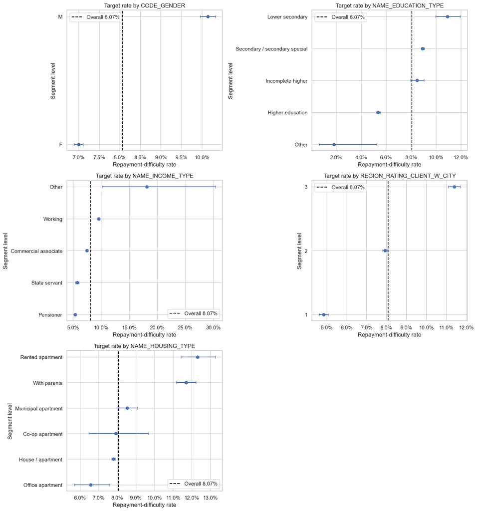

```python
segment_fields = ["CODE_GENDER", "NAME_EDUCATION_TYPE", "NAME_INCOME_TYPE", "REGION_RATING_CLIENT_W_CITY", "NAME_HOUSING_TYPE"]
overall_rate = train["TARGET"].mean()
segment_rows = []
share_rows = []
pooled_values = {}
for c in segment_fields:
    tr_group = supported_groups(train[c])
    kept = set(tr_group.unique())
    te_raw = test[c].fillna("<MISSING>").astype(str)
    te_group = te_raw.where(te_raw.isin(kept), "Other")
    pooled_values[c] = tr_group
    grouped = pd.DataFrame({"level": tr_group, "TARGET": train["TARGET"]}).groupby("level")["TARGET"].agg(["size", "sum", "mean"]).reset_index()
    for _, row in grouped.iterrows():
        lo, hi = wilson(row["sum"], row["size"])
        ratio = row["mean"]/overall_rate
        ci_excludes = hi < overall_rate or lo > overall_rate
        note = row["size"] >= MIN_GROUP and ci_excludes and (ratio >= 1.25 or ratio <= .80)
        threat = row["size"] >= MIN_GROUP and ci_excludes and (ratio >= 2.0 or ratio <= .50)
        segment_rows.append({
            "segment": c, "level": row["level"], "n": int(row["size"]), "share": row["size"]/len(train),
            "target_n": int(row["sum"]), "target_rate": row["mean"], "ci_low": lo, "ci_high": hi,
            "absolute_difference": row["mean"]-overall_rate, "relative_to_overall": ratio,
            "status": "Threatens stability" if threat else "Note" if note else "No flag",
        })
    tr_share = tr_group.value_counts(normalize=True)
    te_share = te_group.value_counts(normalize=True)
    for level in sorted(set(tr_share.index).union(te_share.index)):
        share_rows.append({"segment": c, "level": level, "train_share": tr_share.get(level, 0), "test_share": te_share.get(level, 0), "test_minus_train_pp": 100*(te_share.get(level, 0)-tr_share.get(level, 0))})

segment_profile = pd.DataFrame(segment_rows).sort_values(["segment", "target_rate"], ascending=[True, False])
segment_shares = pd.DataFrame(share_rows).sort_values(["segment", "test_minus_train_pp"], ascending=[True, False])
display(segment_profile)
display(segment_shares)

top_numeric = univariate.loc[(univariate["type"] == "numeric") & (univariate["headline_eligible"] == True), "variable"].head(3).tolist()
stability_rows = []
for segment in segment_fields:
    levels = pooled_values[segment]
    for level in levels.value_counts().loc[lambda s: s >= MIN_GROUP].index:
        mask = levels == level
        y = train.loc[mask, "TARGET"]
        for predictor in top_numeric:
            x = train.loc[mask, predictor]
            valid = x.notna()
            if valid.sum() < MIN_GROUP or x[valid].nunique() < 2 or y[valid].nunique() < 2:
                continue
            score = x[valid]
            raw_auc = roc_auc_score(y[valid], score)
            lo_oriented, hi_oriented = auc_ci(max(raw_auc, 1-raw_auc), int(y[valid].sum()), int((1-y[valid]).sum()))
            if raw_auc >= .5:
                lo, hi = lo_oriented, hi_oriented
            else:
                lo, hi = 1-hi_oriented, 1-lo_oriented
            stability_rows.append({"segment": segment, "level": level, "predictor": predictor, "n_nonmissing": int(valid.sum()), "signed_auc": raw_auc, "ci_low": lo, "ci_high": hi})
stability_matrix = pd.DataFrame(stability_rows)

reversal_rows = []
for (segment, predictor), group in stability_matrix.groupby(["segment", "predictor"]):
    higher = group[group["ci_low"] > .5]
    lower = group[group["ci_high"] < .5]
    reversal_rows.append({
        "segment": segment, "predictor": predictor,
        "supported_levels": len(group), "confident_positive_levels": len(higher),
        "confident_negative_levels": len(lower), "direction_reversal": bool(len(higher) and len(lower)),
    })
reversal_summary = pd.DataFrame(reversal_rows)
display(stability_matrix.head(40))
display(reversal_summary)

fig, axes = plt.subplots(3, 2, figsize=(14, 15))
for ax, c in zip(axes.flat, segment_fields):
    p = segment_profile[segment_profile["segment"] == c].sort_values("target_rate")
    ax.errorbar(p["target_rate"], range(len(p)), xerr=[p["target_rate"]-p["ci_low"], p["ci_high"]-p["target_rate"]], fmt="o", capsize=3)
    ax.axvline(overall_rate, color="black", linestyle="--", label=f"Overall {overall_rate:.2%}")
    ax.set_yticks(range(len(p)))
    ax.set_yticklabels(p["level"])
    ax.set(title=f"Target rate by {c}", xlabel="Repayment-difficulty rate", ylabel="Segment level")
    ax.xaxis.set_major_formatter(plt.FuncFormatter(lambda x, _: f"{x:.1%}"))
    ax.legend()
axes.flat[-1].axis("off")
plt.tight_layout()
plt.show()
```

Default rates vary a lot by segment. People renting default at 12.31% and people living with parents at 11.70%, against 7.80% for people in their own home. The lowest-rated regions default at 11.40% and the highest at 4.84%. Education runs from 10.93% at lower secondary to 5.36% for higher education. Nine individual levels across the five segment variables crossed the 1.25 times line I set in advance; none reached 2.0. Men default at 10.14% against 7.00% for women, which I report as a fairness check rather than a risk factor, since sex cannot be used in underwriting.

The reversal test is narrower than it first appears, and I want to state its scope exactly. I checked three predictors — EXT_SOURCE_2, EXT_SOURCE_3 and DAYS_BIRTH — across five segment variables, and none changed direction. That is evidence about those three predictors in those segments, not about every predictor everywhere. It is also same-direction evidence only: predictive strength, calibration and error rates could differ materially between groups without the sign flipping. And it is entirely cross-sectional and in-sample, so it says nothing about stability over time or in another market, which is the question my BPS actually raises.

One segment shows why I set a minimum group size. NAME_INCOME_TYPE = Other has the highest rate in the table at 18.18%, but only 55 applicants, and its confidence interval runs from 10.2% to 30.3%. I report it here as an illustration of the rule rather than as a finding — 55 people cannot support a conclusion.

# 10 Final audit — anything missed?

## 10.1 Additional checks against the BPS, dictionary, six data-integrity questions, and underwriter plausibility

```python
additional_checks = []
def add_check(area, check, train_count, test_count, status, treatment_or_limit):
    additional_checks.append({"area": area, "check": check, "train_count": int(train_count), "test_count": int(test_count), "status": status, "treatment_or_limit": treatment_or_limit})

for c in ["AMT_INCOME_TOTAL", "AMT_CREDIT", "AMT_ANNUITY", "AMT_GOODS_PRICE"]:
    add_check("underwriter plausibility", f"{c} <= 0", (train_raw[c] <= 0).sum(), (test_raw[c] <= 0).sum(), "review if nonzero", "do not form ratios with non-positive denominator")

train_age = -train_raw["DAYS_BIRTH"]/365.25
test_age = -test_raw["DAYS_BIRTH"]/365.25
add_check("dictionary/time", "age outside 18–100 years", ((train_age < 18) | (train_age > 100)).sum(), ((test_age < 18) | (test_age > 100)).sum(), "review if nonzero", "verify DAYS_BIRTH sign and domain")
add_check("underwriter plausibility", "CNT_CHILDREN > CNT_FAM_MEMBERS", (train_raw.CNT_CHILDREN > train_raw.CNT_FAM_MEMBERS).sum(), (test_raw.CNT_CHILDREN > test_raw.CNT_FAM_MEMBERS).sum(), "inconsistent household count", "flag for repair/review")
add_check("underwriter plausibility", "CNT_FAM_MEMBERS < 1", (train_raw.CNT_FAM_MEMBERS < 1).sum(), (test_raw.CNT_FAM_MEMBERS < 1).sum(), "review if nonzero", "flag for repair/review")
add_check("underwriter plausibility", "DEF_30 count exceeds OBS_30 count", (train_raw.DEF_30_CNT_SOCIAL_CIRCLE > train_raw.OBS_30_CNT_SOCIAL_CIRCLE).sum(), (test_raw.DEF_30_CNT_SOCIAL_CIRCLE > test_raw.OBS_30_CNT_SOCIAL_CIRCLE).sum(), "logical contradiction if nonzero", "exclude affected social-circle values from claims")
add_check("underwriter plausibility", "DEF_60 count exceeds OBS_60 count", (train_raw.DEF_60_CNT_SOCIAL_CIRCLE > train_raw.OBS_60_CNT_SOCIAL_CIRCLE).sum(), (test_raw.DEF_60_CNT_SOCIAL_CIRCLE > test_raw.OBS_60_CNT_SOCIAL_CIRCLE).sum(), "logical contradiction if nonzero", "exclude affected social-circle values from claims")
add_check("underwriter plausibility", "car age present while FLAG_OWN_CAR=N", ((train_raw.FLAG_OWN_CAR == "N") & train_raw.OWN_CAR_AGE.notna()).sum(), ((test_raw.FLAG_OWN_CAR == "N") & test_raw.OWN_CAR_AGE.notna()).sum(), "ownership contradiction if nonzero", "review record consistency")
add_check("underwriter plausibility", "car age missing while FLAG_OWN_CAR=Y", ((train_raw.FLAG_OWN_CAR == "Y") & train_raw.OWN_CAR_AGE.isna()).sum(), ((test_raw.FLAG_OWN_CAR == "Y") & test_raw.OWN_CAR_AGE.isna()).sum(), "availability gap", "treat missingness explicitly")
add_check("underwriter plausibility", "AMT_ANNUITY > AMT_CREDIT", (train_raw.AMT_ANNUITY > train_raw.AMT_CREDIT).sum(), (test_raw.AMT_ANNUITY > test_raw.AMT_CREDIT).sum(), "implausible current-loan relation", "review rather than delete")
for c in ["EXT_SOURCE_1", "EXT_SOURCE_2", "EXT_SOURCE_3"]:
    add_check("dictionary/domain", f"{c} outside [0,1]", ((train_raw[c] < 0) | (train_raw[c] > 1)).sum(), ((test_raw[c] < 0) | (test_raw[c] > 1)).sum(), "dictionary contradiction if nonzero", "exclude or repair only with documented rule")

additional_audit = pd.DataFrame(additional_checks)
display(additional_audit)

bps_and_scope_audit = pd.DataFrame([
    {"source": "BPS", "item": "approval-threshold trade-off", "status": "deferred, not omitted", "what_is_required": "out-of-sample scores, held-out validation, and a stated missed-default/declined-good cost ratio"},
    {"source": "BPS", "item": "calibration, precision, and recall", "status": "modeling-stage item", "what_is_required": "a fitted predictive model evaluated on held-out observations"},
    {"source": "BPS", "item": "cross-market and temporal stability", "status": "not answerable here", "what_is_required": "labeled current local or time-indexed external data"},
    {"source": "BPS", "item": "outcomes for declined applicants", "status": "not observed", "what_is_required": "reject-inference design or additional outcome data; approval rates remain simulated"},
    {"source": "BPS versus EDA scope", "item": "bureau, prior applications, and repayment behavior", "status": "scoped future work", "what_is_required": "application-date-safe aggregation of supplementary history tables"},
    {"source": "dictionary", "item": "EXT_SOURCE provenance and timestamp", "status": "undocumented", "what_is_required": "provider, construction, component, and as-of-date documentation"},
    {"source": "approved rubric", "item": "meaningful Q1 signal below stand-alone threshold", "status": "defined at AUC 0.55 post hoc", "what_is_required": "set after reviewing the ranking, not pre-registered; sensitivity untested at other converting Review fields to Pass"},
    {"source": "governance", "item": "fair-lending permissibility", "status": "flagged, not resolved", "what_is_required": "jurisdiction-specific compliance and governance review"},
])
display(bps_and_scope_audit)
```

|  | area | check | train_count | test_count | status | treatment_or_limit |
| --- | --- | --- | --- | --- | --- | --- |
| 0 | underwriter plausibility | AMT_INCOME_TOTAL <= 0 | 0 | 0 | review if nonzero | do not form ratios with non-positive denominator |
| 1 | underwriter plausibility | AMT_CREDIT <= 0 | 0 | 0 | review if nonzero | do not form ratios with non-positive denominator |
| 2 | underwriter plausibility | AMT_ANNUITY <= 0 | 0 | 0 | review if nonzero | do not form ratios with non-positive denominator |
| 3 | underwriter plausibility | AMT_GOODS_PRICE <= 0 | 0 | 0 | review if nonzero | do not form ratios with non-positive denominator |
| 4 | dictionary/time | age outside 18–100 years | 0 | 0 | review if nonzero | verify DAYS_BIRTH sign and domain |
| 5 | underwriter plausibility | CNT_CHILDREN > CNT_FAM_MEMBERS | 0 | 0 | inconsistent household count | flag for repair/review |
| 6 | underwriter plausibility | CNT_FAM_MEMBERS < 1 | 0 | 0 | review if nonzero | flag for repair/review |
| 7 | underwriter plausibility | DEF_30 count exceeds OBS_30 count | 0 | 0 | logical contradiction if nonzero | exclude affected social-circle values from claims |
| 8 | underwriter plausibility | DEF_60 count exceeds OBS_60 count | 0 | 0 | logical contradiction if nonzero | exclude affected social-circle values from claims |
| 9 | underwriter plausibility | car age present while FLAG_OWN_CAR=N | 0 | 0 | ownership contradiction if nonzero | review record consistency |
| 10 | underwriter plausibility | car age missing while FLAG_OWN_CAR=Y | 5 | 1 | availability gap | treat missingness explicitly |
| 11 | underwriter plausibility | AMT_ANNUITY > AMT_CREDIT | 0 | 0 | implausible current-loan relation | review rather than delete |
| 12 | dictionary/domain | EXT_SOURCE_1 outside [0,1] | 0 | 0 | dictionary contradiction if nonzero | exclude or repair only with documented rule |
| 13 | dictionary/domain | EXT_SOURCE_2 outside [0,1] | 0 | 0 | dictionary contradiction if nonzero | exclude or repair only with documented rule |
| 14 | dictionary/domain | EXT_SOURCE_3 outside [0,1] | 0 | 0 | dictionary contradiction if nonzero | exclude or repair only with documented rule |

|  | source | item | status | what_is_required |
| --- | --- | --- | --- | --- |
| 0 | BPS | approval-threshold trade-off | deferred, not omitted | out-of-sample scores, held-out validation, and... |
| 1 | BPS | calibration, precision, and recall | modeling-stage item | a fitted predictive model evaluated on held-ou... |
| 2 | BPS | cross-market and temporal stability | not answerable here | labeled current local or time-indexed external... |
| 3 | BPS | outcomes for declined applicants | not observed | reject-inference design or additional outcome ... |
| 4 | BPS versus EDA scope | bureau, prior applications, and repayment beha... | scoped future work | application-date-safe aggregation of supplemen... |
| 5 | dictionary | EXT_SOURCE provenance and timestamp | undocumented | provider, construction, component, and as-of-d... |
| 6 | approved rubric | meaningful Q1 signal below stand-alone threshold | defined at AUC 0.55 post hoc | set after reviewing the ranking, not pre-regis... |
| 7 | governance | fair-lending permissibility | flagged, not resolved | jurisdiction-specific compliance and governanc... |

The additional checks came back clean. No non-positive incomes, credits, annuities or goods prices. No ages outside 18 to 100. No household counts that contradict each other, no cases where defaulted social-circle contacts exceed observed ones, and no EXT_SOURCE values outside the documented 0 to 1 range. The only exception is six applicants, five in training and one in test, recorded as owning a car with no car age. That is a gap in availability rather than a contradiction, and it is too small to affect anything.

The second table lists what this EDA cannot settle. Three are modeling-stage items: the approval threshold trade-off, calibration, and precision and recall, all of which need a fitted model scored out of sample. Two are outside the data entirely.I cannot test cross-market or temporal stability without a second labeled sample, and I cannot measure outcomes for declined applicants because those rows do not exist. One is a scope decision: bureau and prior-application history is deferred, with the coverage numbers in my data map to justify it. One is a documentation gap I cannot close, which is EXT_SOURCE provenance. The last is a governance item I have flagged rather than resolved, since fair-lending permissibility is a compliance judgment and not something this data can answer.

# 11 Results

**Key data problems, and the data-preparation decisions they force.** Five findings change how the data must be prepared. `DAYS_EMPLOYED = 365243` affects 18% of rows and is a pensioner sentinel, not a duration: it becomes missing, with an explicit flag, and the rows are kept because that group is large and systematically lower-risk. The building-characteristics block is missing for roughly 70% of applicants across 19 distinct patterns, and its absence predicts difficulty (9.15% against 6.99%), so those fields need missing-indicators rather than mean imputation. Eleven `FLAG_DOCUMENT` columns are constant in the test set and cannot contribute to scoring at all. Three category levels exist only in training and need explicit handling at encode time. And one test row carries an impossible region rating, repaired rather than dropped because every test applicant must receive a prediction. Seventy-one numeric pairs correlate above 0.90 and collapse to 15 groups, reducing 121 candidate columns to 85 numeric groups.

**The strongest relationships with the target.** None is strong. The best single predictor, `EXT_SOURCE_2`, reaches a held-out AUC of 0.654; the best predictor that can be explained to an applicant, `DAYS_BIRTH`, reaches 0.585. Nothing met the standard set in advance for a variable standing on its own. Segment differences are larger than any single variable: default runs from 4.84% in the highest-rated regions to 11.40% in the lowest, from 5.36% for higher education to 10.93% at lower secondary, and reaches 12.31% among renters. Among the money variables, risk peaks in the middle of the loan-size distribution and falls at both ends rather than rising monotonically.

# 12 Limitations

An adversarial review of this notebook raised objections I could not fully resolve at this stage. I record them here rather than leave a reader to find them.

- **Reproducibility.** The source CSVs are unchanged and all repairs happen in derived frames, but reproducing the exact analysis population requires re-running this notebook in order. There is no saved preprocessing object and no test proving train and test receive identical treatment.
- **The sentinel label.** FLAG_NOT_EMPLOYED is named for what the code appears to mean, not for a documented definition, and it is overwhelmingly a pensioner marker. I did not test whether the lower default rate in that group survives controlling for age.
- **Threshold choices.** The 0.55 signal bar, the 0.90 redundancy cut, the 1,000 minimum group size and the 60% missingness limit are judgment calls. Only the 0.70 stand-alone bar was set before seeing results, and I did not test how the shortlist changes at other values.
- **Verifiability is asserted, not measured.** The tiers come from the data dictionary. I have no evidence about how any field is verified in practice.
- **The impossible-value register is a hand-selected list of checks**, not a systematic domain audit of all 122 fields.
- **Grain is established at application level only.** Without a person identifier I cannot test whether the same applicant appears more than once, which also means the confidence intervals assume independent observations.
- **Everything here is in-sample and cross-sectional.** Nothing tests performance out of time, in another market, or under an approval-cost function.

# 13 How I used AI

I used Claude inside Positron under a stage-gated workflow: separate conversations for data mapping, industry-feature research, planning, execution, and adversarial critique, with my own written approval required between stages.

**What AI did.** Catalogued the tables and columns for the data map; researched and cited the industry feature literature; drafted the EDA plan from my question list; and produced first drafts of the interpretive writing, which I reviewed and revised.

**What I did.** Wrote the question list and interpretive writng; set every threshold in the screen and approved each data treatment with a stated reason; ruled on the objections raised in the critique stage; and decided which findings to keep.

**How it went.** AI was most reliable for mechanical enumeration — cataloguing 122 columns, checking category levels across train and test, assembling the scorecard. It was least reliable at interpretation, and confidently so. The critique stage caught several claims in the draft interpretations that the data did not support:

- The money variables were described as flat or monotonic when the binned default rates are clearly humped. The rank correlation I relied on was near zero precisely because the relationship is non-monotonic.
- The train/test category risk was stated backwards.
- A comparison of two univariate AUCs was presented as the cost of excluding EXT_SOURCE.
- A reversal test covering three predictors was described as covering all of them.
- A claim that the building columns were missing on identical rows, when there are 19 distinct missingness patterns.

I corrected each of these.